# Data Science Final Project

All

Jason Brant

December 12, 2018

# Overview

There is no consensus on the ideal treatment protocol for stereotactic radiosurgery of benign intracranial tumors such as meningioma and acoustic neuroma. The patient, tumor, and treatment facility factors that lead to radiation as part of primary treatment for these tumors is unknown. Here, benign intracranial tumors included in the National Cancer Database (NCDB) are analyzed to determine these factors, as well as similar factors that impact those receiving radiation.

# Introduction

There is no agreed upon protocol for treatment of benign intracranial tumors. Most commonly meningiomas or neuromas, these tumors tend to be slow growing and cause symptoms by mass effect on surrounding structures. Although they tend to grow slowly, without treatment they tend to increase in size until they become symptomatic. Historically, they were discovered at this late stage as only large tumors would be able to be seen on pre-MRI imaging or would be found at the time of surgical exploration. Increasingly, tumors are being found incidentally as more patients are imaged for a variety of reasons. Discovery of small, asymptomatic tumors presents a dilemma. Surgery often reuslts in significant morbidity, monitoring tumors can lead to further growth and increased impact of treatment down the road, and radiation carries its own side effects without removing the tumor.

This study uses the National Cancer Database (NCDB) to investigate patient, tumor, and facility factors that are correlated with the use of radiation as part of primary treatment for benign intracranial tumors. The NCDB is jointly sponsored by the American College of Surgeons and the American Cancer Society and is a clinical oncology database with data collected from >1500 Commis- sion on Cancer accredited facilities. The NCDB, established in 1989, is a nationwide, facility-based, comprehensive clini- cal surveillance resource oncology dataset that includes >34 million records and represents >70% of newly diagnosed cancer cases in the United States. The NCDB uses the International Classification of Diseases for Oncology for topography (primary site) and morphology (histology) definitions. Generally, The NCDB only includes patients with malignant tumors, but it also includes benign tumors of the brain and spinal cord (CNS - central nervous system). The treatment variables included in the NCDB represent primary treatments - those initiated within 60 days of diagnosis. There is no information regarding secondary treatments, or treatment failures.

This project touches on clinical questions that overlap several fields as well as relies on statistical evaluation of large datasets. For this project, input from neurosurgery, radiation oncology, and biostatistics was included. Clinically, patients with benign tumors of the CNS are cared for by neurosurgery, radiation oncology, and otorhinolaryngology depending on location of the tumors and specific symptosm of concern.

There are no large scale studies that evaluate patient, tumor, and facility-related factors associated with the use of radiation as part of primary treatment for these tumors.

# Methods

The NCDB was queried for cases present in the CNS (“C700”, “C710”, “C711”, “C712”, “C713”, “C714”, “C715”, “C716”, “C717”, “C718”, “C719”, “C709”, “C722”, “C723”, “C724”, “C725”, “C728”, “C729”) from 2004 to 2014.

Descriptive statistics are presented as frequencies for categorical variables and means with standard deviation (SD) for continuous variables. Overall survival was the primary outcome of interest. Individual variable correlation with survival was analyzed using univariable and multivariable Cox proportional hazards models. The final multivariable model included the following variables: age, sex, race, hispanic, treatment facility type, insurance status, income, education, tumor size, treatment, comorbidity score, and year of diagnosis. Logistic regression modeling with the same variables (except treatment) was used to evaluate which factors had an impact on the inclusion of radiation as part of primary treatment. In logistic model analyses, incomplete cases were removed.

The subset of patients who underwent radiation as part of their primary treatment was then analyzed. A multivariable model with the above variables plus type of radiation was utilized to evaluate how socioeconomic and demographic characteristics of subjects correlated with treatment decisions including radiation as part of treatment, and type of radiation used.

```r
#NCDB data is obtained as fixed width formatted text files
#Setting the column widths
col.width <- c(37, 10, 1, 1, 3, 1, 2, 1, 2, 1, 1, 1, 1, 1, 1, 8, 2, 2, 2, 4, 4, 1, 4, 1, 1, 1, 3, 2, 2, 8,
               2, 5, 5, 5, 4, 5, 5, 5, 4, 2, 1, 2, 1, 3, 1, 1, 1, 1, 1, 1, 3, 3, 3, 3, 3, 3, 3, 3, 3, 3, 3,
               3, 3, 3, 3, 3, 3, 3, 3, 3, 3, 3, 3, 3, 3, 6, 8, 8, 8, 2, 1, 1, 1, 1, 8, 1, 1, 8, 1, 1, 2,
               2, 5, 2, 5, 3, 1, 3, 1, 8, 8, 2, 8, 2, 8, 2, 2, 1, 8, 1, 1, 1, 1, 1, 8, 1, 2, 2, 2, 2, 2,
               1, 1, 1, 2, 1)
#Establishing column names
col.names.abr <- c("PUF_CASE_ID", "PUF_FACILITY_ID", "FACILITY_TYPE_CD",  "FACILITY_LOCATION_CD", "AGE", "SEX", "RACE",
                   "SPANISH_HISPANIC_ORIGIN", "INSURANCE_STATUS", "MED_INC_QUAR_00", "NO_HSD_QUAR_00", "UR_CD_03",
                   "MED_INC_QUAR_12", "NO_HSD_QUAR_12", "UR_CD_13", "CROWFLY", "CDCC_TOTAL", "SEQUENCE_NUMBER",
                   "CLASS_OF_CASE", "YEAR_OF_DIAGNOSIS", "PRIMARY_SITE",  "LATERALITY", "HISTOLOGY", "BEHAVIOR",
                   "GRADE", "DIAGNOSTIC_CONFIRMATION", "TUMOR_SIZE", "REGIONAL_NODES_POSITIVE",
                   "REGIONAL_NODES_EXAMINED", "DX_STAGING_PROC_DAYS", "RX_SUMM_DXSTG_PROC", "TNM_CLIN_T",
                   "TNM_CLIN_N", "TNM_CLIN_M", "TNM_CLIN_STAGE_GROUP", "TNM_PATH_T", "TNM_PATH_N", "TNM_PATH_M",
                   "TNM_PATH_STAGE_GROUP", "TNM_EDITION_NUMBER", "ANALYTIC_STAGE_GROUP", "CS_METS_AT_DX",
                   "CS_METS_EVAL", "CS_EXTENSION", "CS_TUMOR_SIZEEXT_EVAL", "CS_METS_DX_BONE",
                   "CS_METS_DX_BRAIN", "CS_METS_DX_LIVER", "CS_METS_DX_LUNG", "LYMPH_VASCULAR_INVASION",
                   "CS_SITESPECIFIC_FACTOR_1", "CS_SITESPECIFIC_FACTOR_2", "CS_SITESPECIFIC_FACTOR_3",
                   "CS_SITESPECIFIC_FACTOR_4", "CS_SITESPECIFIC_FACTOR_5", "CS_SITESPECIFIC_FACTOR_6",
                   "CS_SITESPECIFIC_FACTOR_7", "CS_SITESPECIFIC_FACTOR_8", "CS_SITESPECIFIC_FACTOR_9",
                   "CS_SITESPECIFIC_FACTOR_10", "CS_SITESPECIFIC_FACTOR_11", "CS_SITESPECIFIC_FACTOR_12",
                   "CS_SITESPECIFIC_FACTOR_13", "CS_SITESPECIFIC_FACTOR_14", "CS_SITESPECIFIC_FACTOR_15",
                   "CS_SITESPECIFIC_FACTOR_16", "CS_SITESPECIFIC_FACTOR_17", "CS_SITESPECIFIC_FACTOR_18",
                   "CS_SITESPECIFIC_FACTOR_19", "CS_SITESPECIFIC_FACTOR_20", "CS_SITESPECIFIC_FACTOR_21",
                   "CS_SITESPECIFIC_FACTOR_22", "CS_SITESPECIFIC_FACTOR_23", "CS_SITESPECIFIC_FACTOR_24",
                   "CS_SITESPECIFIC_FACTOR_25", "CS_VERSION_LATEST", "DX_RX_STARTED_DAYS",
                   "DX_SURG_STARTED_DAYS", "DX_DEFSURG_STARTED_DAYS", "RX_SUMM_SURG_PRIM_SITE",
                   "RX_HOSP_SURG_APPR_2010", "RX_SUMM_SURGICAL_MARGINS", "RX_SUMM_SCOPE_REG_LN_SUR",
                   "RX_SUMM_SURG_OTH_REGDIS", "SURG_DISCHARGE_DAYS", "READM_HOSP_30_DAYS",
                   "REASON_FOR_NO_SURGERY", "DX_RAD_STARTED_DAYS", "RX_SUMM_RADIATION", "RAD_LOCATION_OF_RX",
                   "RAD_TREAT_VOL", "RAD_REGIONAL_RX_MODALITY", "RAD_REGIONAL_DOSE_CGY",
                   "RAD_BOOST_RX_MODALITY", "RAD_BOOST_DOSE_CGY", "RAD_NUM_TREAT_VOL",
                   "RX_SUMM_SURGRAD_SEQ", "RAD_ELAPSED_RX_DAYS", "REASON_FOR_NO_RADIATION",
                   "DX_SYSTEMIC_STARTED_DAYS", "DX_CHEMO_STARTED_DAYS", "RX_SUMM_CHEMO",
                   "DX_HORMONE_STARTED_DAYS", "RX_SUMM_HORMONE", "DX_IMMUNO_STARTED_DAYS",
                   "RX_SUMM_IMMUNOTHERAPY", "RX_SUMM_TRNSPLNT_ENDO", "RX_SUMM_SYSTEMIC_SUR_SEQ",
                   "DX_OTHER_STARTED_DAYS", "RX_SUMM_OTHER", "PALLIATIVE_CARE", "RX_SUMM_TREATMENT_STATUS",
                   "PUF_30_DAY_MORT_CD", "PUF_90_DAY_MORT_CD", "DX_LASTCONTACT_DEATH_MONTHS",
                   "PUF_VITAL_STATUS", "RX_HOSP_SURG_PRIM_SITE", "RX_HOSP_CHEMO", "RX_HOSP_IMMUNOTHERAPY",
                   "RX_HOSP_HORMONE", "RX_HOSP_OTHER", "PUF_MULT_SOURCE", "REFERENCE_DATE_FLAG",
                   "RX_SUMM_SCOPE_REG_LN_2012", "RX_HOSP_DXSTG_PROC", "PALLIATIVE_CARE_HOSP")
#Read in data for each subsite
brain <- read_fwf('I:/Brant/Research/NCDB/Data/Data_2017/NCDB_PUF_DATA_Nov-07-2017/NCDBPUF_Brain.3.2015.0.dat',
                       fwf_widths(col.width, col_names = col.names.abr),
                       col_types = cols(.default = col_character()))
cns <- read_fwf('I:/Brant/Research/NCDB/Data/Data_2017/NCDB_PUF_DATA_Nov-07-2017/NCDBPUF_CNS.3.2015.0.dat',
                       fwf_widths(col.width, col_names = col.names.abr),
                       col_types = cols(.default = col_character()))
#Combine data for all subsites
dat <- bind_rows( brain, cns)
rm(brain, cns)
#Determine variables that should be treated as factors
fact_vars <- c("PRIMARY_SITE", "FACILITY_TYPE_CD", "FACILITY_LOCATION_CD", "SEX", "RACE", "SPANISH_HISPANIC_ORIGIN",
               "INSURANCE_STATUS", "MED_INC_QUAR_00", "NO_HSD_QUAR_00", "UR_CD_03", "MED_INC_QUAR_12",
               "NO_HSD_QUAR_12", "UR_CD_13", "CDCC_TOTAL", "SEQUENCE_NUMBER", "CLASS_OF_CASE",
               "YEAR_OF_DIAGNOSIS", "LATERALITY", "HISTOLOGY", "BEHAVIOR",
               "GRADE", "DIAGNOSTIC_CONFIRMATION", "REGIONAL_NODES_POSITIVE", "REGIONAL_NODES_EXAMINED",
               "RX_SUMM_DXSTG_PROC", "TNM_CLIN_T",
               "TNM_CLIN_N", "TNM_CLIN_M", "TNM_CLIN_STAGE_GROUP", "TNM_PATH_T", "TNM_PATH_N",
               "TNM_PATH_M", "TNM_PATH_STAGE_GROUP", "TNM_EDITION_NUMBER", "ANALYTIC_STAGE_GROUP",
               "CS_METS_AT_DX", "CS_METS_EVAL", "CS_EXTENSION", "CS_TUMOR_SIZEEXT_EVAL", "CS_METS_DX_BONE",
               "CS_METS_DX_BRAIN", "CS_METS_DX_LIVER", "CS_METS_DX_LUNG", "LYMPH_VASCULAR_INVASION",
               "CS_VERSION_LATEST", "RX_SUMM_SURG_PRIM_SITE", "RX_HOSP_SURG_APPR_2010", "RX_SUMM_SURGICAL_MARGINS",
               "RX_SUMM_SCOPE_REG_LN_SUR", "RX_SUMM_SURG_OTH_REGDIS", "READM_HOSP_30_DAYS", "REASON_FOR_NO_SURGERY",
               "RX_SUMM_RADIATION",
               "RAD_LOCATION_OF_RX", "RAD_TREAT_VOL", "RAD_REGIONAL_RX_MODALITY", "RAD_BOOST_RX_MODALITY",
               "RX_SUMM_SURGRAD_SEQ", "REASON_FOR_NO_RADIATION", "RX_SUMM_CHEMO", "RX_SUMM_HORMONE",
               "RX_SUMM_IMMUNOTHERAPY", "RX_SUMM_TRNSPLNT_ENDO", "RX_SUMM_SYSTEMIC_SUR_SEQ",
               "RX_SUMM_OTHER", "PALLIATIVE_CARE", "RX_SUMM_TREATMENT_STATUS", "PUF_30_DAY_MORT_CD",
               "PUF_90_DAY_MORT_CD", "RX_HOSP_SURG_PRIM_SITE", "RX_HOSP_CHEMO", "RX_HOSP_IMMUNOTHERAPY",
               "RX_HOSP_HORMONE", "RX_HOSP_OTHER", "PUF_MULT_SOURCE", "REFERENCE_DATE_FLAG",
               "RX_SUMM_SCOPE_REG_LN_2012",   'RX_HOSP_DXSTG_PROC', 'PALLIATIVE_CARE_HOSP')
dat[fact_vars] <- lapply(dat[fact_vars], as.character)
dat[fact_vars] <- lapply(dat[fact_vars], as.factor)
#Determine variables that should be treated as numeric
num_vars <- c("AGE", "CROWFLY", "TUMOR_SIZE", "DX_STAGING_PROC_DAYS", "DX_RX_STARTED_DAYS", "DX_SURG_STARTED_DAYS",
              "DX_DEFSURG_STARTED_DAYS", "SURG_DISCHARGE_DAYS", "DX_RAD_STARTED_DAYS",  "RAD_REGIONAL_DOSE_CGY",
              "RAD_BOOST_DOSE_CGY", "RAD_ELAPSED_RX_DAYS", "DX_SYSTEMIC_STARTED_DAYS", "DX_CHEMO_STARTED_DAYS",
              "DX_HORMONE_STARTED_DAYS", "DX_OTHER_STARTED_DAYS", "DX_LASTCONTACT_DEATH_MONTHS",
              "RAD_NUM_TREAT_VOL")
dat[num_vars] <- lapply(dat[num_vars], as.numeric)
```

```r
#Create function for easier table creation
p_table <- function(tab_data, ...) {
  tab_data_2 <- deparse(substitute(tab_data))

  table_p <- do.call(CreateTableOne,
                     list(data = as.name(tab_data_2), includeNA = TRUE, ...))
  table_p_out <- print(table_p,
                       showAllLevels = TRUE,
                       printToggle = FALSE)
  kable(table_p_out,
        align = "c")
}
```

```r
#Create function for logistic regression and forest plot of results
f_plot <- function(test_var, data_imp){

        cat("_________________________________________________")
        cat("\n")
        cat("   \n##", test_var)
        cat("\n")
        cat("_________________________________________________")
        cat("\n")

        f <- as.formula(paste(as.name(test_var),
                              "INSURANCE_F + AGE_F + SEX_F + RACE_F + INCOME_F + U_R_F + CDCC_TOTAL + FACILITY_TYPE_F + EDUCATION_F + T_SIZE + HISPANIC + YEAR_OF_DIAGNOSIS",
                              sep = " ~ " ))

        data_imp_2 <- deparse(substitute(data_imp))

        fit_fn <- do.call("glm",
                       list(formula = f,
                            data = as.name(data_imp_2),
                            family = "binomial"))

        print(summary(fit_fn))

        or <- as.data.frame(exp(coefficients(fit_fn)))
        or$Variable <- rownames(or)
        rownames(or) <- c()
        names(or) <- c('OddsRatio', 'Variable')
        ci <- as.data.frame(exp(confint(fit_fn)))
        ci$Variable <- rownames(ci)
        rownames(ci) <- c()
        p_val_list <- tidy(fit_fn) %>%
        select(term, p.value) %>%
        rename(Variable = term) %>%
        mutate(p.value = round(p.value, 4))
        p_val_list$p.value <- as.character(p_val_list$p.value)
        p_val_list$p.value[p_val_list$p.value == "0"] <- "< 0.0001"
        all <- full_join(or, ci, by = 'Variable')
        all <- full_join(all, p_val_list, by = "Variable")
        names(all) <- c('OddsRatio', 'Variable', 'Lower', 'Upper', "p_value")
        all <- na.omit(all)
        all <- all %>%
        filter(Variable != '(Intercept)')
        text <- cbind(c("Variable", as.character(all$Variable)),
              c("Odds Ratio", as.character(round(all$OddsRatio, 2))),
              c("Lower CI", as.character(round(all$Lower, 2))),
              c("Upper CI", as.character(round(all$Upper, 2))),
              c("p Value", all$p_value))
        forestplot(text,
           mean = c(NA, all$OddsRatio),
           lower = c(NA, all$Lower),
           upper = c(NA, all$Upper),
           new_page =   TRUE, zero = 1,
           clip = c(0.1, 100),
           hrzl_lines = list("2" = gpar(col="#444444")),
           vertices = TRUE,
           graph.pos = 2,
           xlab = "Odds Ratio (log)",
           align = "c",
           txt_gp = fpTxtGp(cex = 0.7),
           xticks = getTicks(low = all$Lower,
                             high = all$Upper,
                             clip=c(-Inf, Inf),
                             exp=TRUE),
           boxsize = 0.1)

}
```

```r
#Select sites of interest and behavior codes of interest
site_code <- c("C700", "C710", "C711", "C712", "C713", "C714", "C715", "C716",
               "C717", "C718", "C719", "C709", "C722", "C723", "C724", "C725",
               "C728", "C729")
histo_code <- c("All Histology")
behavior_code <- c("0", "1")
#Create subset of data based on site and behavior codes
data <- dat %>%
        filter(BEHAVIOR %in% behavior_code) %>%
        filter(PRIMARY_SITE %in% site_code) %>%
        filter(is.na(PUF_VITAL_STATUS) == FALSE) %>%
        filter(is.na(DX_LASTCONTACT_DEATH_MONTHS) == FALSE)
```

1. Site codes: C700, C710, C711, C712, C713, C714, C715, C716, C717, C718, C719, C709, C722, C723, C724, C725, C728, C729
2. Histology codes: All Histology
3. Behavior codes: 0, 1

Patients were excluded if they didn’t have values for either follow up or vital status.

```r
data <- data %>%
        mutate(FACILITY_TYPE_F = fct_recode(FACILITY_TYPE_CD,
                                            "Community Cancer Program" = "1",
                                            "Comprehensive Comm Ca Program" = "2",
                                            "Academic/Research Program" = "3",
                                            "Integrated Network Ca Program" = "4",
                                            "Other" = "9")) %>%
        mutate(FACILITY_LOCATION_F = fct_recode(FACILITY_LOCATION_CD,
                                            "New England" = "1",
                                            "Middle Atlantic" = "2",
                                            "South Atlantic" = "3",
                                            "East North Central" = "4",
                                            "East South Central" = "5",
                                            "West North Central" = "6",
                                            "West South Central" = "7",
                                            "Mountain" = "8",
                                            "Pacific" = "9",
                                            "out of US" = "0")) %>%
        mutate(FACILITY_GEOGRAPHY = fct_collapse(FACILITY_LOCATION_CD,
                                                 "Northeast" = c("1", "2"),
                                                 "South" = c("3", "7"),
                                                 "Midwest" = c("4", "5", "6"),
                                                 "West" = c("8", "9"))) %>%
        mutate(AGE_F = cut(AGE, c(0, 54, 64, 74, 100))) %>%
        mutate(AGE_40 = cut(AGE, c(0, 40, 100))) %>%
        mutate(SEX_F = fct_recode(SEX,
                                "Male" = "1",
                                "Female" = "2")) %>%
        mutate(RACE_F = fct_collapse(RACE,
                                "White" = c("01"),
                                "Black" = c("02"),
                                "Asian" = c("04", "05", "06", "07", "08", "10", "11", "12", "13", "14", "15",
                                            "16", "17", "20", "21", "22", "25", "26", "27", "28", "30", "31",
                                            "32", "96", "97"),
                                "Other/Unk" = c("03", "98", "99"))) %>%
        mutate(HISPANIC = fct_collapse(SPANISH_HISPANIC_ORIGIN,
                                       "Yes" = c("1", "2", "3", "4", "5", "6", "7", "8"),
                                       "No" = c("0"),
                                       "Unknown" = c("9"))) %>%
        mutate(INSURANCE_F = fct_recode(INSURANCE_STATUS,
                                         "None" = "0",
                                         "Private" = "1",
                                         "Medicaid" = "2",
                                         "Medicare" = "3",
                                         "Other Government" = "4",
                                         "Unknown" = "9")) %>%
        mutate(INSURANCE_F = fct_relevel(INSURANCE_F,
                                         "Private")) %>%
        mutate(INCOME_F = fct_recode(MED_INC_QUAR_12,
                                      "Less than 38k" = "1",
                                      "38k to 47k" = "2",
                                      "48k to 63k" = "3",
                                      "Over 63k" = "4")) %>%
        mutate(EDUCATION_F = fct_recode(NO_HSD_QUAR_12,
                                        "21% or more" = "1",
                                        "13 - 20.9%" = "2",
                                        "7 - 12.9%" = "3",
                                        "Less than 7%" = "4")) %>%
        mutate(U_R_F = fct_collapse(UR_CD_13,
                                    "Metro" = c("1", "2", "3"),
                                    "Urban" = c("4", "5", "6", "7"),
                                    "Rural" = c("8", "9"))) %>%
        mutate(CLASS_OF_CASE_F = fct_collapse(CLASS_OF_CASE,
                                              All_Part_Prim = c("10", "11", "12", "13",
                                                                "14", "20", "21", "22"),
                                              Other_Facility = c("00"))) %>%
        mutate(GRADE_F = fct_recode(GRADE,
                                  "Gr I: Well Diff" = "1",
                                  "Gr II: Mod Diff" = "2",
                                  "Gr III: Poor Diff" = "3",
                                  "Gr IV: Undiff/Anaplastic" = "4",
                                  "NA/Unkown" = "9")) %>%
        mutate(HISTOLOGY_F = fct_infreq(HISTOLOGY)) %>%
        mutate(HISTOLOGY_F = factor(HISTOLOGY_F)) %>%
        mutate(HISTOLOGY_F_LIM = fct_lump(HISTOLOGY_F, prop = 0.05)) %>%
        mutate(TNM_CLIN_T = fct_recode(TNM_CLIN_T,
                                       "N_A" = "88")) %>%
        mutate(TNM_CLIN_T = fct_relevel(TNM_CLIN_T,
                                        "1")) %>%
        mutate(TNM_CLIN_N = fct_recode(TNM_CLIN_N,
                                       "N_A" = "88")) %>%
        mutate(TNM_CLIN_M = fct_recode(TNM_CLIN_M,
                                       "N_A" = "88")) %>%
        mutate(TNM_PATH_T = fct_recode(TNM_PATH_T,
                                       "N_A" = "88")) %>%
        mutate(TNM_PATH_T = fct_relevel(TNM_PATH_T,
                                        "1")) %>%
        mutate(TNM_PATH_N = fct_recode(TNM_PATH_N,
                                       "N_A" = "88")) %>%
        mutate(TNM_PATH_M = fct_recode(TNM_PATH_M,
                                       "N_A" = "88")) %>%
        mutate(TNM_CLIN_STAGE_GROUP = fct_recode(TNM_CLIN_STAGE_GROUP,
                                       "N_A" = "88")) %>%
        mutate(TNM_PATH_STAGE_GROUP = fct_recode(TNM_PATH_STAGE_GROUP,
                                       "N_A" = "88")) %>%
        mutate(MARGINS = fct_recode(RX_SUMM_SURGICAL_MARGINS,
                                    "No Residual" = "0",
                                    "Residual, NOS" = "1",
                                    "Microscopic Resid" = "2",
                                    "Macroscopic Resid" = "3",
                                    "Not evaluable" = "7",
                                    "No surg" = "8",
                                    "Unknown" = "9")) %>%
        mutate(MARGINS_YN = fct_collapse(RX_SUMM_SURGICAL_MARGINS,
                                         "Yes" = c("1", "2", "3"),
                                         "No" = c("0"),
                                         "No surg/Unk/NA" = c("7", "8", "9"))) %>%
        mutate(READM_HOSP_30_DAYS_F = fct_recode(READM_HOSP_30_DAYS,
                                                 "No_Surg_or_No_Readmit" = "0",
                                                 "Unplan_Readmit_Same" = "1",
                                                 "Plan_Readmit_Same" = "2",
                                                 "PlanUnplan_Same" = "3",
                                                 "Unknown" = "4")) %>%
        mutate(RX_SUMM_RADIATION_F = fct_recode(RX_SUMM_RADIATION,
                                                "None" = "0",
                                                "Beam Radiation" = "1",
                                                "Radioactive Implants" = "2",
                                                "Radioisotopes" = "3",
                                                "Beam + Imp or Isotopes" = "4",
                                                "Radiation, NOS" = "5",
                                                "Unknown" = "9")) %>%
        mutate(PUF_30_DAY_MORT_CD_F = fct_recode(PUF_30_DAY_MORT_CD,
                                                 "Alive_30" = "0",
                                                 "Dead_30" = "1",
                                                 "Unknown" = "9")) %>%
        mutate(PUF_90_DAY_MORT_CD_F = fct_recode(PUF_90_DAY_MORT_CD,
                                                 "Alive_90" = "0",
                                                 "Dead_90" = "1",
                                                 "Unknown" = "9")) %>%
        mutate(LYMPH_VASCULAR_INVASION_F = fct_recode(LYMPH_VASCULAR_INVASION,
                                                      "Neg_LymphVasc_Inv" = "0",
                                                      "Pos_LumphVasc_Inv" = "1",
                                                      "N_A" = "8",
                                                      "Unknown" = "9")) %>%
        mutate(RX_HOSP_SURG_APPR_2010_F = fct_recode(RX_HOSP_SURG_APPR_2010,
                                                     "No_Surg" = "0",
                                                     "Robot_Assist" = "1",
                                                     "Robot_to_Open" = "2",
                                                     "Endo_Lap" = "3",
                                                     "Endo_Lap_to_Open" = "4",
                                                     "Open_Unknown" = "5",
                                                     "Unknown" = "9")) %>%
        mutate(All = "All") %>%
        mutate(All = factor(All)) %>%
        mutate(REASON_FOR_NO_SURGERY_F = fct_recode(REASON_FOR_NO_SURGERY,
                                                    "Surg performed" = "0",
                                                    "Surg not recommended" = "1",
                                                    "No surg due to pt factors" = "2",
                                                    "No surg, pt died" = "5",
                                                    "Surg rec, not done" = "6",
                                                    "Surg rec, pt refused" = "7",
                                                    "Surg rec, unk if done" = "8",
                                                    "Unknown" = "9")) %>%
        mutate(SURGERY_YN = ifelse(REASON_FOR_NO_SURGERY == "0",
                                   "Yes",
                                   ifelse(REASON_FOR_NO_SURGERY == "9",
                                          "Ukn",
                                          "No"))) %>%
        mutate(REASON_FOR_NO_RADIATION_F = fct_recode(REASON_FOR_NO_RADIATION,
                                                    "Rad performed" = "0",
                                                    "Rad not recommended" = "1",
                                                    "No Rad due to pt factors" = "2",
                                                    "No Rad, pt died" = "5",
                                                    "Rad rec, not done" = "6",
                                                    "Rad rec, pt refused" = "7",
                                                    "Rad rec, unk if done" = "8",
                                                    "Unknown" = "9")) %>%
        mutate(RADIATION_YN = ifelse(REASON_FOR_NO_RADIATION == "0",
                                   "Yes",
                                   ifelse(REASON_FOR_NO_RADIATION == "9",
                                          "Ukn",
                                          "No"))) %>%
        mutate(SURGRAD_SEQ_F = fct_recode(RX_SUMM_SURGRAD_SEQ,
                                                   "None or Surg or Rad" = "0",
                                                   "Rad before Surg" = "2",
                                                   "Surg before Rad" = "3",
                                                   "Rad before and after Surg" = "4",
                                                   "Intraop Rad" = "5",
                                                   "Intraop Rad plus other" = "6",
                                                   "Unknown" = "9")) %>%
        mutate(SURG_RAD_SEQ = ifelse(SURGERY_YN == "Yes" & RX_SUMM_SURGRAD_SEQ == "0",
```

```r
                                     "Surg Alone",
                                     ifelse(RADIATION_YN == "Yes" & RX_SUMM_SURGRAD_SEQ == "0",
                                            "Rad Alone",
                                            ifelse(SURGERY_YN == "No" & RADIATION_YN == "No" & RX_SUMM_SURGRAD_SEQ == "0",
                                                   "No Treatment",
                                                   ifelse(RX_SUMM_SURGRAD_SEQ == "2",
                                                          "Rad then Surg",
                                                          ifelse(RX_SUMM_SURGRAD_SEQ == "3",
                                                                 "Surg then Rad",
                                                                 ifelse(RX_SUMM_SURGRAD_SEQ == "4",
                                                                        "Rad before and after Surg",
                                                                        "Other"))))))) %>%
        mutate(SURG_RAD_SEQ = fct_relevel(SURG_RAD_SEQ,
                                          "Surg Alone",
                                          "Surg then Rad",
                                          "Rad Alone")) %>%
        mutate(CHEMO_YN = fct_collapse(RX_SUMM_CHEMO,
                                       "No" = c("00", "82", "85", "86", "87"),
                                       "Yes" = c("01", "02", "03"),
                                       "Ukn" = c("88", "99"))) %>%
        mutate(SURG_RAD_SEQ_C = ifelse(SURGERY_YN == "Yes" & RX_SUMM_SURGRAD_SEQ == "0" & CHEMO_YN == "No",
                                     "Surg, No rad, No Chemo",
                                     ifelse(RADIATION_YN == "Yes" & RX_SUMM_SURGRAD_SEQ == "0" & CHEMO_YN == "No",
                                            "Rad, No Surg, No Chemo",
                                            ifelse(SURGERY_YN == "No" & RADIATION_YN == "No" & RX_SUMM_SURGRAD_SEQ == "0" & CHEMO_YN == "No",
                                                   "No Surg, No Rad, No Chemo",
                                                   ifelse(RX_SUMM_SURGRAD_SEQ == "2" & CHEMO_YN == "No",
                                                          "Rad then Surg, No Chemo",
                                                          ifelse(RX_SUMM_SURGRAD_SEQ == "3" & CHEMO_YN == "No",
                                                                 "Surg then Rad, No Chemo",
                                                                 ifelse(RX_SUMM_SURGRAD_SEQ == "4" & CHEMO_YN == "No",
                                                                        "Rad before and after Surg, No Chemo",
                                ifelse(SURGERY_YN == "Yes" & RX_SUMM_SURGRAD_SEQ == "0" & CHEMO_YN == "Yes",
                                       "Surg, No rad, Yes Chemo",
                                       ifelse(RADIATION_YN == "Yes" & RX_SUMM_SURGRAD_SEQ == "0" & CHEMO_YN == "Yes",
                                              "Rad, No Surg, Yes Chemo",
                                              ifelse(SURGERY_YN == "No" & RADIATION_YN == "No" & RX_SUMM_SURGRAD_SEQ == "0" & CHEMO_YN == "Yes",
                                                     "No Surg, No Rad, Yes Chemo",
                                                     ifelse(RX_SUMM_SURGRAD_SEQ == "2" & CHEMO_YN == "Yes",
                                                            "Rad then Surg, Yes Chemo",
                                                            ifelse(RX_SUMM_SURGRAD_SEQ == "3" & CHEMO_YN == "Yes",
                                                                   "Surg then Rad, Yes Chemo",
                                                                   ifelse(RX_SUMM_SURGRAD_SEQ == "4" & CHEMO_YN == "Yes",
                                                                          "Rad before and after Surg, Yes Chemo",
                                                                          "Other"))))))))))))) %>%
        mutate(SURG_RAD_SEQ_C = fct_infreq(SURG_RAD_SEQ_C)) %>%
        mutate(T_SIZE = as.numeric(TUMOR_SIZE)) %>%
        mutate(T_SIZE = ifelse(T_SIZE == 0,
                                "No Tumor",
                                ifelse(T_SIZE > 0 & T_SIZE < 10 | T_SIZE == 991,
                                       "< 1 cm",
                                       ifelse(T_SIZE >= 10 & T_SIZE < 20 | T_SIZE == 992,
                                              "1-2 cm",
                                              ifelse(T_SIZE >= 20 & T_SIZE < 30 | T_SIZE == 993,
                                                     "2-3 cm",
                                                     ifelse(T_SIZE >= 30 & T_SIZE < 40 | T_SIZE == 994,
                                                            "3-4 cm",
                                                            ifelse(T_SIZE >= 40 & T_SIZE < 50 | T_SIZE == 995,
                                                                   "4-5 cm",
                                                                   ifelse(T_SIZE >= 50 & T_SIZE < 60 | T_SIZE == 996,
                                                                          "5-6 cm",
                                                                          ifelse(T_SIZE >= 60 & T_SIZE <= 987 |
                                                                                         T_SIZE == 980 | T_SIZE == 989 |
                                                                                         T_SIZE == 997,
                                                                          ">6 cm",
                                                                          ifelse(T_SIZE == 988 | T_SIZE == 999,
                                                                                 "NA_unk",
                                                                                 "Microscopic focus")))))))))) %>%
        mutate(T_SIZE = factor(T_SIZE)) %>%
        mutate(T_SIZE = fct_relevel(T_SIZE,
                                     "No Tumor", "Microscopic focus", "< 1 cm", "1-2 cm", "2-3 cm", "3-4 cm",
                                       "4-5 cm", "5-6 cm", ">6 cm", "NA_unk")) %>%
        mutate(mets_at_dx = case_when(CS_METS_DX_LUNG == "1" ~ "Lung",
                                      CS_METS_DX_BONE == "1" ~ "Bone",
                                      CS_METS_DX_BRAIN == "1" ~ "Brain",
                                      CS_METS_DX_LIVER == "1" ~ "Liver",
                                      TRUE ~ "None/Other/Unk/NA"))
```

[output not shown]

```r
fact_vars_2 <- c("FACILITY_TYPE_F", "FACILITY_LOCATION_F", "AGE_F", "SEX_F", "RACE_F",
                 "HISPANIC", "INSURANCE_F", "INCOME_F", "EDUCATION_F", "U_R_F",
                 "CDCC_TOTAL", "CLASS_OF_CASE_F", "YEAR_OF_DIAGNOSIS", "PRIMARY_SITE", "HISTOLOGY",
                 "BEHAVIOR", "GRADE_F", "TNM_CLIN_T", "TNM_CLIN_N", "TNM_CLIN_M",
                 "TNM_CLIN_STAGE_GROUP", "TNM_PATH_T", "TNM_PATH_N", "TNM_PATH_M", "TNM_PATH_STAGE_GROUP",
                 "MARGINS", "READM_HOSP_30_DAYS_F", "RX_SUMM_RADIATION_F", "PUF_30_DAY_MORT_CD_F",
                 "PUF_90_DAY_MORT_CD_F", "LYMPH_VASCULAR_INVASION_F", "RX_HOSP_SURG_APPR_2010_F", "mets_at_dx")
data <- data %>%
        mutate_at(fact_vars_2, funs(factor(.)))
```

# Results

## Table of variables for all cases:

```r
p_table(data,
        vars = c("FACILITY_TYPE_F", "AGE", "AGE_F",
                 "SEX_F", "RACE_F", "HISPANIC", "INSURANCE_F",
                 "INCOME_F", "EDUCATION_F", "U_R_F", "CROWFLY", "CDCC_TOTAL",
                 "PRIMARY_SITE", "HISTOLOGY_F_LIM", "BEHAVIOR",
                  "RX_SUMM_RADIATION_F", "PUF_30_DAY_MORT_CD_F",
                 "PUF_90_DAY_MORT_CD_F", "DX_LASTCONTACT_DEATH_MONTHS",
                  "SURG_RAD_SEQ", "T_SIZE", "SURGERY_YN", "RADIATION_YN", "CHEMO_YN"))
```

|  | level | Overall |
| --- | --- | --- |
| n |  | 255751 |
| FACILITY_TYPE_F (%) | Community Cancer Program | 13313 ( 5.2) |
|  | Comprehensive Comm Ca Program | 84250 (32.9) |
|  | Academic/Research Program | 97390 (38.1) |
|  | Integrated Network Ca Program | 29993 (11.7) |
|  | NA | 30805 (12.0) |
| AGE (mean (sd)) |  | 60.17 (17.64) |
| AGE_F (%) | (0,54] | 90713 (35.5) |
|  | (54,64] | 54517 (21.3) |
|  | (64,74] | 50605 (19.8) |
|  | (74,100] | 59518 (23.3) |
|  | NA | 398 ( 0.2) |
| SEX_F (%) | Male | 82812 (32.4) |
|  | Female | 172939 (67.6) |
| RACE_F (%) | White | 211385 (82.7) |
|  | Black | 28267 (11.1) |
|  | Other/Unk | 8150 ( 3.2) |
|  | Asian | 7949 ( 3.1) |
| HISPANIC (%) | No | 223738 (87.5) |
|  | Yes | 16595 ( 6.5) |
|  | Unknown | 15418 ( 6.0) |
| INSURANCE_F (%) | Private | 114589 (44.8) |
|  | None | 10339 ( 4.0) |
|  | Medicaid | 16908 ( 6.6) |
|  | Medicare | 104534 (40.9) |
|  | Other Government | 3326 ( 1.3) |
|  | Unknown | 6055 ( 2.4) |
| INCOME_F (%) | Less than 38k | 42251 (16.5) |
|  | 38k to 47k | 57872 (22.6) |
|  | 48k to 63k | 69013 (27.0) |

[output cut: 80 more lines]

## Influence of patient, tumor, and facility factors on radiation as part of initial treatment

### Univariable

```r
data <- data %>% mutate(RADIATION_YN = as.factor(data$RADIATION_YN))  %>%
        mutate(YEAR_OF_DIAGNOSIS = fct_relevel(YEAR_OF_DIAGNOSIS,
                                               "2004", after = 0)) %>%
        mutate(FACILITY_TYPE_F = fct_relevel(FACILITY_TYPE_F,
                                               "Academic/Research Program", after = 0)) %>%
        mutate(T_SIZE = fct_relevel(T_SIZE,
                                               "< 1 cm", after = 0))
# excluding patients for whom radiation therapy information was not available
noUkns <- data %>% filter(RADIATION_YN != "Ukn")
```

#### Insurance

```r
fit_ins <- glm(RADIATION_YN ~ INSURANCE_F,
               data = noUkns,
               family = "binomial")
summary(fit_ins)
```

```
Call:
glm(formula = RADIATION_YN ~ INSURANCE_F, family = "binomial",
    data = noUkns)

Deviance Residuals:
    Min       1Q   Median       3Q      Max
-0.6061  -0.5651  -0.4552  -0.4552   2.2191

Coefficients:
                             Estimate Std. Error  z value Pr(>|z|)
(Intercept)                 -1.753786   0.008378 -209.343  < 2e-16 ***
INSURANCE_FNone             -0.619247   0.036412  -17.007  < 2e-16 ***
INSURANCE_FMedicaid         -0.368647   0.026396  -13.966  < 2e-16 ***
INSURANCE_FMedicare         -0.460972   0.013382  -34.446  < 2e-16 ***
INSURANCE_FOther Government  0.152365   0.047444    3.211  0.00132 **
INSURANCE_FUnknown          -0.049180   0.038104   -1.291  0.19682
---
Signif. codes:  0 *** 0.001 ** 0.01 * 0.05 . 0.1   1

(Dispersion parameter for binomial family taken to be 1)

    Null deviance: 187966  on 252876  degrees of freedom
Residual deviance: 186486  on 252871  degrees of freedom
AIC: 186498

Number of Fisher Scoring iterations: 4
```

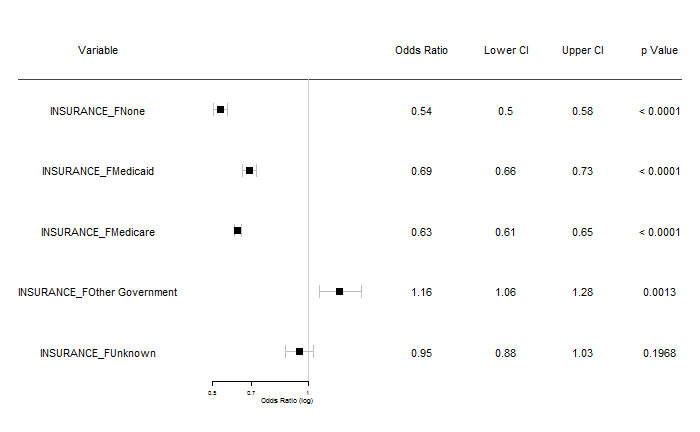

```r
or <- as.data.frame(exp(coefficients(fit_ins)))
        or$Variable <- rownames(or)
        rownames(or) <- c()
        names(or) <- c('OddsRatio', 'Variable')
        ci <- as.data.frame(exp(confint(fit_ins)))
        ci$Variable <- rownames(ci)
        rownames(ci) <- c()
        p_val_list <- tidy(fit_ins) %>%
        select(term, p.value) %>%
        rename(Variable = term) %>%
        mutate(p.value = round(p.value, 4))
        p_val_list$p.value <- as.character(p_val_list$p.value)
        p_val_list$p.value[p_val_list$p.value == "0"] <- "< 0.0001"
        all <- full_join(or, ci, by = 'Variable')
        all <- full_join(all, p_val_list, by = "Variable")
        names(all) <- c('OddsRatio', 'Variable', 'Lower', 'Upper', "p_value")
        all <- na.omit(all)
        all <- all %>%
        filter(Variable != '(Intercept)')
        text <- cbind(c("Variable", as.character(all$Variable)),
              c("Odds Ratio", as.character(round(all$OddsRatio, 2))),
              c("Lower CI", as.character(round(all$Lower, 2))),
              c("Upper CI", as.character(round(all$Upper, 2))),
              c("p Value", all$p_value))
                forestplot(text,
           mean = c(NA, all$OddsRatio),
           lower = c(NA, all$Lower),
           upper = c(NA, all$Upper),
           new_page =   TRUE, zero = 1,
           clip = c(0.1, 100),
           hrzl_lines = list("2" = gpar(col="#444444")),
           vertices = TRUE,
           graph.pos = 2,
           xlab = "Odds Ratio (log)",
           align = "c",
           txt_gp = fpTxtGp(cex = 0.7),
           xticks = getTicks(low = all$Lower,
                             high = all$Upper,
                             clip=c(-Inf, Inf),
                             exp=TRUE),
           boxsize = 0.1)
```

#### Age

```r
fit_age <- glm(RADIATION_YN ~ AGE_F,
               data = noUkns,
               family = "binomial")
summary(fit_age)
```

```
Call:
glm(formula = RADIATION_YN ~ AGE_F, family = "binomial", data = noUkns)

Deviance Residuals:
    Min       1Q   Median       3Q      Max
-0.5709  -0.5383  -0.5268  -0.3879   2.2911

Coefficients:
               Estimate Std. Error  z value Pr(>|z|)
(Intercept)   -1.858720   0.009779 -190.064  < 2e-16 ***
AGE_F(54,64]   0.126924   0.015518    8.179 2.86e-16 ***
AGE_F(64,74]  -0.046097   0.016512   -2.792  0.00524 **
AGE_F(74,100] -0.690670   0.018666  -37.001  < 2e-16 ***
---
Signif. codes:  0 *** 0.001 ** 0.01 * 0.05 . 0.1   1

(Dispersion parameter for binomial family taken to be 1)

    Null deviance: 187860  on 252486  degrees of freedom
Residual deviance: 185771  on 252483  degrees of freedom
  (390 observations deleted due to missingness)
AIC: 185779

Number of Fisher Scoring iterations: 5
```

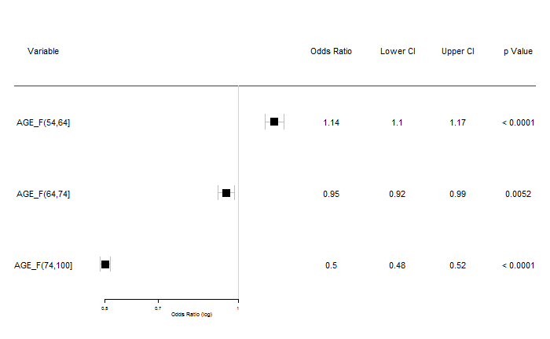

```r
or <- as.data.frame(exp(coefficients(fit_age)))
        or$Variable <- rownames(or)
        rownames(or) <- c()
        names(or) <- c('OddsRatio', 'Variable')
        ci <- as.data.frame(exp(confint(fit_age)))
        ci$Variable <- rownames(ci)
        rownames(ci) <- c()
        p_val_list <- tidy(fit_age) %>%
        select(term, p.value) %>%
        rename(Variable = term) %>%
        mutate(p.value = round(p.value, 4))
        p_val_list$p.value <- as.character(p_val_list$p.value)
        p_val_list$p.value[p_val_list$p.value == "0"] <- "< 0.0001"
        all <- full_join(or, ci, by = 'Variable')
        all <- full_join(all, p_val_list, by = "Variable")
        names(all) <- c('OddsRatio', 'Variable', 'Lower', 'Upper', "p_value")
        all <- na.omit(all)
        all <- all %>%
        filter(Variable != '(Intercept)')
        text <- cbind(c("Variable", as.character(all$Variable)),
              c("Odds Ratio", as.character(round(all$OddsRatio, 2))),
              c("Lower CI", as.character(round(all$Lower, 2))),
              c("Upper CI", as.character(round(all$Upper, 2))),
              c("p Value", all$p_value))
        forestplot(text,
           mean = c(NA, all$OddsRatio),
           lower = c(NA, all$Lower),
           upper = c(NA, all$Upper),
           new_page =   TRUE, zero = 1,
           clip = c(0.1, 100),
           hrzl_lines = list("2" = gpar(col="#444444")),
           vertices = TRUE,
           graph.pos = 2,
           xlab = "Odds Ratio (log)",
           align = "c",
           txt_gp = fpTxtGp(cex = 0.7),
           xticks = getTicks(low = all$Lower,
                             high = all$Upper,
                             clip=c(-Inf, Inf),
                             exp=TRUE),
           boxsize = 0.1)
```

#### Facility Type

```r
fit_fac <- glm(RADIATION_YN ~ FACILITY_TYPE_F,
               data = noUkns,
               family = "binomial")
summary(fit_fac)
```

```
Call:
glm(formula = RADIATION_YN ~ FACILITY_TYPE_F, family = "binomial",
    data = noUkns)

Deviance Residuals:
    Min       1Q   Median       3Q      Max
-0.5715  -0.5691  -0.4566  -0.4566   2.5432

Coefficients:
                                              Estimate Std. Error  z value Pr(>|z|)
(Intercept)                                  -1.738550   0.009025 -192.634   <2e-16 ***
FACILITY_TYPE_FCommunity Cancer Program      -1.455127   0.045801  -31.770   <2e-16 ***
FACILITY_TYPE_FComprehensive Comm Ca Program -0.469706   0.014705  -31.941   <2e-16 ***
FACILITY_TYPE_FIntegrated Network Ca Program  0.009271   0.018577    0.499    0.618
---
Signif. codes:  0 *** 0.001 ** 0.01 * 0.05 . 0.1   1

(Dispersion parameter for binomial family taken to be 1)

    Null deviance: 167021  on 222452  degrees of freedom
Residual deviance: 164645  on 222449  degrees of freedom
  (30424 observations deleted due to missingness)
AIC: 164653

Number of Fisher Scoring iterations: 5
```

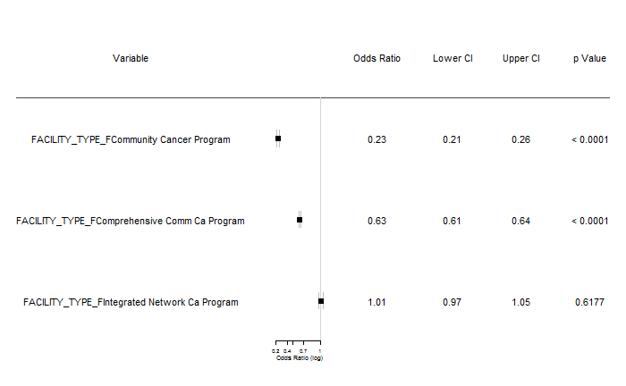

```r
or <- as.data.frame(exp(coefficients(fit_fac)))
        or$Variable <- rownames(or)
        rownames(or) <- c()
        names(or) <- c('OddsRatio', 'Variable')
        ci <- as.data.frame(exp(confint(fit_fac)))
        ci$Variable <- rownames(ci)
        rownames(ci) <- c()
        p_val_list <- tidy(fit_fac) %>%
        select(term, p.value) %>%
        rename(Variable = term) %>%
        mutate(p.value = round(p.value, 4))
        p_val_list$p.value <- as.character(p_val_list$p.value)
        p_val_list$p.value[p_val_list$p.value == "0"] <- "< 0.0001"
        all <- full_join(or, ci, by = 'Variable')
        all <- full_join(all, p_val_list, by = "Variable")
        names(all) <- c('OddsRatio', 'Variable', 'Lower', 'Upper', "p_value")
        all <- na.omit(all)
        all <- all %>%
        filter(Variable != '(Intercept)')
        text <- cbind(c("Variable", as.character(all$Variable)),
              c("Odds Ratio", as.character(round(all$OddsRatio, 2))),
              c("Lower CI", as.character(round(all$Lower, 2))),
              c("Upper CI", as.character(round(all$Upper, 2))),
              c("p Value", all$p_value))
        forestplot(text,
           mean = c(NA, all$OddsRatio),
           lower = c(NA, all$Lower),
           upper = c(NA, all$Upper),
           new_page =   TRUE, zero = 1,
           clip = c(0.1, 100),
           hrzl_lines = list("2" = gpar(col="#444444")),
           vertices = TRUE,
           graph.pos = 2,
           xlab = "Odds Ratio (log)",
           align = "c",
           txt_gp = fpTxtGp(cex = 0.7),
           xticks = getTicks(low = all$Lower,
                             high = all$Upper,
                             clip=c(-Inf, Inf),
                             exp=TRUE),
           boxsize = 0.1)
```

#### Year

```r
fit_year <- glm(RADIATION_YN ~ YEAR_OF_DIAGNOSIS,
               data = noUkns,
               family = "binomial")
summary(fit_year)
```

```
Call:
glm(formula = RADIATION_YN ~ YEAR_OF_DIAGNOSIS, family = "binomial",
    data = noUkns)

Deviance Residuals:
    Min       1Q   Median       3Q      Max
-0.5549  -0.5304  -0.5078  -0.4846   2.1016

Coefficients:
                      Estimate Std. Error z value Pr(>|z|)
(Intercept)           -1.79320    0.02245 -79.870  < 2e-16 ***
YEAR_OF_DIAGNOSIS2005 -0.02951    0.03104  -0.951  0.34170
YEAR_OF_DIAGNOSIS2006 -0.03252    0.03048  -1.067  0.28607
YEAR_OF_DIAGNOSIS2007 -0.09698    0.03042  -3.188  0.00143 **
YEAR_OF_DIAGNOSIS2008 -0.13270    0.03004  -4.418 9.98e-06 ***
YEAR_OF_DIAGNOSIS2009 -0.19006    0.02980  -6.377 1.80e-10 ***
YEAR_OF_DIAGNOSIS2010 -0.16816    0.02966  -5.670 1.43e-08 ***
YEAR_OF_DIAGNOSIS2011 -0.29878    0.03006  -9.941  < 2e-16 ***
YEAR_OF_DIAGNOSIS2012 -0.28302    0.02983  -9.488  < 2e-16 ***
YEAR_OF_DIAGNOSIS2013 -0.28938    0.02968  -9.751  < 2e-16 ***
YEAR_OF_DIAGNOSIS2014 -0.28878    0.02954  -9.775  < 2e-16 ***
---
Signif. codes:  0 *** 0.001 ** 0.01 * 0.05 . 0.1   1

(Dispersion parameter for binomial family taken to be 1)

    Null deviance: 187966  on 252876  degrees of freedom
Residual deviance: 187655  on 252866  degrees of freedom
AIC: 187677

Number of Fisher Scoring iterations: 4
```

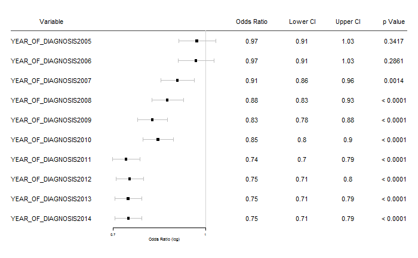

```r
or <- as.data.frame(exp(coefficients(fit_year)))
        or$Variable <- rownames(or)
        rownames(or) <- c()
        names(or) <- c('OddsRatio', 'Variable')
        ci <- as.data.frame(exp(confint(fit_year)))
        ci$Variable <- rownames(ci)
        rownames(ci) <- c()
        p_val_list <- tidy(fit_year) %>%
        select(term, p.value) %>%
        rename(Variable = term) %>%
        mutate(p.value = round(p.value, 4))
        p_val_list$p.value <- as.character(p_val_list$p.value)
        p_val_list$p.value[p_val_list$p.value == "0"] <- "< 0.0001"
        all <- full_join(or, ci, by = 'Variable')
        all <- full_join(all, p_val_list, by = "Variable")
        names(all) <- c('OddsRatio', 'Variable', 'Lower', 'Upper', "p_value")
        all <- na.omit(all)
        all <- all %>%
        filter(Variable != '(Intercept)')
        text <- cbind(c("Variable", as.character(all$Variable)),
              c("Odds Ratio", as.character(round(all$OddsRatio, 2))),
              c("Lower CI", as.character(round(all$Lower, 2))),
              c("Upper CI", as.character(round(all$Upper, 2))),
              c("p Value", all$p_value))
        forestplot(text,
           mean = c(NA, all$OddsRatio),
           lower = c(NA, all$Lower),
           upper = c(NA, all$Upper),
           new_page =   TRUE, zero = 1,
           clip = c(0.1, 100),
           hrzl_lines = list("2" = gpar(col="#444444")),
           vertices = TRUE,
           graph.pos = 2,
           xlab = "Odds Ratio (log)",
           align = "c",
           txt_gp = fpTxtGp(cex = 0.7),
           xticks = getTicks(low = all$Lower,
                             high = all$Upper,
                             clip=c(-Inf, Inf),
                             exp=TRUE),
           boxsize = 0.1)
```

#### Tumor Size

```r
fit_size <- glm(RADIATION_YN ~ T_SIZE,
               data = noUkns,
               family = "binomial")
summary(fit_size)
```

```
Call:
glm(formula = RADIATION_YN ~ T_SIZE, family = "binomial", data = noUkns)

Deviance Residuals:
    Min       1Q   Median       3Q      Max
-0.5613  -0.5311  -0.5170  -0.4498   2.5616

Coefficients:
                        Estimate Std. Error  z value Pr(>|z|)
(Intercept)             -2.24016    0.02216 -101.110  < 2e-16 ***
T_SIZENo Tumor           0.08840    0.33484    0.264    0.792
T_SIZEMicroscopic focus -1.00243    0.45622   -2.197    0.028 *
T_SIZE1-2 cm             0.35266    0.02522   13.984  < 2e-16 ***
T_SIZE2-3 cm             0.47180    0.02601   18.136  < 2e-16 ***
T_SIZE3-4 cm             0.20599    0.02883    7.145 8.97e-13 ***
T_SIZE4-5 cm            -0.01085    0.03299   -0.329    0.742
T_SIZE5-6 cm             0.02247    0.03769    0.596    0.551
T_SIZE>6 cm              0.22933    0.03438    6.670 2.56e-11 ***
T_SIZENA_unk             0.29518    0.02585   11.417  < 2e-16 ***
---
Signif. codes:  0 *** 0.001 ** 0.01 * 0.05 . 0.1   1

(Dispersion parameter for binomial family taken to be 1)

    Null deviance: 187966  on 252876  degrees of freedom
Residual deviance: 187308  on 252867  degrees of freedom
AIC: 187328

Number of Fisher Scoring iterations: 5
```

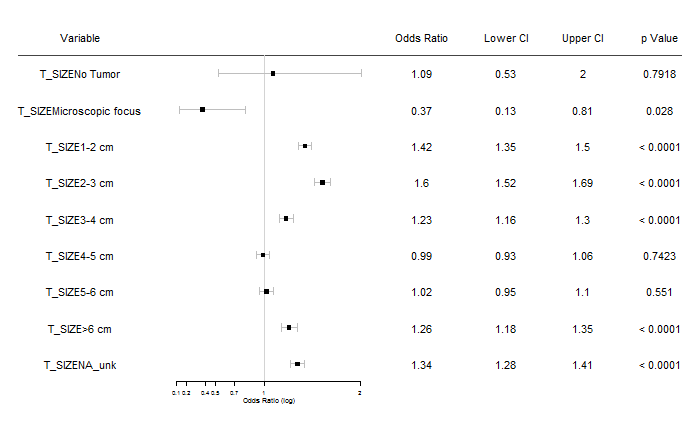

```r
or <- as.data.frame(exp(coefficients(fit_size)))
        or$Variable <- rownames(or)
        rownames(or) <- c()
        names(or) <- c('OddsRatio', 'Variable')
        ci <- as.data.frame(exp(confint(fit_size)))
        ci$Variable <- rownames(ci)
        rownames(ci) <- c()
        p_val_list <- tidy(fit_size) %>%
        select(term, p.value) %>%
        rename(Variable = term) %>%
        mutate(p.value = round(p.value, 4))
        p_val_list$p.value <- as.character(p_val_list$p.value)
        p_val_list$p.value[p_val_list$p.value == "0"] <- "< 0.0001"
        all <- full_join(or, ci, by = 'Variable')
        all <- full_join(all, p_val_list, by = "Variable")
        names(all) <- c('OddsRatio', 'Variable', 'Lower', 'Upper', "p_value")
        all <- na.omit(all)
        all <- all %>%
        filter(Variable != '(Intercept)')
        text <- cbind(c("Variable", as.character(all$Variable)),
              c("Odds Ratio", as.character(round(all$OddsRatio, 2))),
              c("Lower CI", as.character(round(all$Lower, 2))),
              c("Upper CI", as.character(round(all$Upper, 2))),
              c("p Value", all$p_value))
        forestplot(text,
           mean = c(NA, all$OddsRatio),
           lower = c(NA, all$Lower),
           upper = c(NA, all$Upper),
           new_page =   TRUE, zero = 1,
           clip = c(0.1, 100),
           hrzl_lines = list("2" = gpar(col="#444444")),
           vertices = TRUE,
           graph.pos = 2,
           xlab = "Odds Ratio (log)",
           align = "c",
           txt_gp = fpTxtGp(cex = 0.7),
           xticks = getTicks(low = all$Lower,
                             high = all$Upper,
                             clip=c(-Inf, Inf),
                             exp=TRUE),
           boxsize = 0.1)
```

### Multivariable

Summary of model and forest plot of odds ratios with confidence intervals.

```
_________________________________________________

## RADIATION_YN
_________________________________________________

Call:
glm(formula = RADIATION_YN ~ INSURANCE_F + AGE_F + SEX_F + RACE_F +
    INCOME_F + U_R_F + CDCC_TOTAL + FACILITY_TYPE_F + EDUCATION_F +
    T_SIZE + HISPANIC + YEAR_OF_DIAGNOSIS, family = "binomial",
    data = noUkns)

Deviance Residuals:
    Min       1Q   Median       3Q      Max
-0.9904  -0.5797  -0.4621  -0.3235   3.0950

Coefficients:
                                              Estimate Std. Error z value Pr(>|z|)
(Intercept)                                  -1.572628   0.043786 -35.916  < 2e-16 ***
INSURANCE_FNone                              -0.559473   0.042792 -13.074  < 2e-16 ***
INSURANCE_FMedicaid                          -0.197834   0.032398  -6.106 1.02e-09 ***
INSURANCE_FMedicare                          -0.152953   0.021191  -7.218 5.29e-13 ***
INSURANCE_FOther Government                   0.196263   0.052763   3.720 0.000199 ***
INSURANCE_FUnknown                           -0.003143   0.042579  -0.074 0.941167
AGE_F(54,64]                                  0.084567   0.017365   4.870 1.12e-06 ***
AGE_F(64,74]                                  0.062363   0.023561   2.647 0.008123 **
AGE_F(74,100]                                -0.490035   0.026407 -18.557  < 2e-16 ***
SEX_FFemale                                  -0.261784   0.014037 -18.650  < 2e-16 ***
RACE_FBlack                                  -0.090633   0.023889  -3.794 0.000148 ***
RACE_FOther/Unk                               0.149515   0.037138   4.026 5.68e-05 ***
RACE_FAsian                                   0.072159   0.038716   1.864 0.062352 .
INCOME_F38k to 47k                           -0.005199   0.023907  -0.217 0.827858
INCOME_F48k to 63k                            0.075977   0.025160   3.020 0.002530 **
INCOME_FOver 63k                              0.075961   0.028172   2.696 0.007011 **
U_R_FUrban                                    0.161361   0.020739   7.781 7.22e-15 ***
U_R_FRural                                    0.176151   0.052462   3.358 0.000786 ***
CDCC_TOTAL1                                  -0.634981   0.021438 -29.620  < 2e-16 ***
CDCC_TOTAL2                                  -1.022253   0.043464 -23.520  < 2e-16 ***
CDCC_TOTAL3                                  -1.227693   0.067451 -18.201  < 2e-16 ***
FACILITY_TYPE_FCommunity Cancer Program      -1.311841   0.046987 -27.919  < 2e-16 ***
FACILITY_TYPE_FComprehensive Comm Ca Program -0.361986   0.015394 -23.514  < 2e-16 ***
```

[output cut: 21 more lines]

```
YEAR_OF_DIAGNOSIS2011                        -0.240678   0.033415  -7.203 5.90e-13 ***
YEAR_OF_DIAGNOSIS2012                        -0.210801   0.033103  -6.368 1.91e-10 ***
YEAR_OF_DIAGNOSIS2013                        -0.227424   0.033026  -6.886 5.73e-12 ***
YEAR_OF_DIAGNOSIS2014                        -0.221152   0.032898  -6.722 1.79e-11 ***
---
Signif. codes:  0 *** 0.001 ** 0.01 * 0.05 . 0.1   1

(Dispersion parameter for binomial family taken to be 1)

    Null deviance: 160869  on 215378  degrees of freedom
Residual deviance: 153028  on 215331  degrees of freedom
  (37498 observations deleted due to missingness)
AIC: 153124

Number of Fisher Scoring iterations: 6
```

[figure not shown]

```r
f_plot("RADIATION_YN", noUkns)
```

## Overall Survival Analysis

```r
#Create function for univariable survival analysis and KM curves
uni_var <- function(test_var, data_imp) {

        cat("_________________________________________________")
        cat("\n")
        cat("   \n##", test_var)
        cat("\n")
        cat("_________________________________________________")
        cat("\n")

        f <- as.formula(paste("Surv(DX_LASTCONTACT_DEATH_MONTHS, PUF_VITAL_STATUS == 0)",
                              as.name(test_var),
                              sep = " ~ " ))

        data_imp_2 <- deparse(substitute(data_imp))
        km_fit <- do.call("survfit", list(formula = f, data = as.name(data_imp_2)))
        print(km_fit)
        cat("\n")
        print(summary(km_fit, times = c(12, 24, 36, 48, 60, 120)))
        cat("\n")
        cat("\n")
        cat("\n")
        cat("   \n## Univariable Cox Proportional Hazard Model for: ", test_var)
        cat("\n")
        cat("\n")
        n_levels <- nlevels(data_imp[[test_var]])
        if(n_levels == 1){
                print("Only one level, no Cox model performed")
                cat("\n")
        } else {
                cox_fit <- do.call("coxph", list(formula = f, data = as.name(data_imp_2)))
                print(summary(cox_fit))
                cat("\n")

                do.call("ggforest",
                         list(model = cox_fit, data = as.name(data_imp_2)))
        }
        cat("\n")
        cat("\n")
        cat("\n")
        cat("   \n## Unadjusted Kaplan Meier Overall Survival Curve for: ", test_var)
        p <- do.call("ggsurvplot",
                     list(fit = km_fit, data = as.name(data_imp_2),
                          palette = "jco", censor = FALSE, legend = "right",
                          linetype = "strata", xlab = "Time (Months)"))
        print(p)
}
```

Univariables overall survival analysis for potential variables of interest. For this analysis all patients were included. For each variable, median survival as well as percentage survival at 12, 24, 36, 48, 60, and 120 months are calculated for each variable value. A univariable cox proportional hazard ratio analysis is then performed and Kaplan-Meier survival curve plotted.

### All

```
_________________________________________________

## All
_________________________________________________
Call: survfit(formula = Surv(DX_LASTCONTACT_DEATH_MONTHS, PUF_VITAL_STATUS ==
    0) ~ All, data = data)

      n  events  median 0.95LCL 0.95UCL
 255751   54325     155     155      NA

Call: survfit(formula = Surv(DX_LASTCONTACT_DEATH_MONTHS, PUF_VITAL_STATUS ==
    0) ~ All, data = data)

 time n.risk n.event survival  std.err lower 95% CI upper 95% CI
   12 216097   20395    0.917 0.000558        0.916        0.918
   24 187719    7960    0.882 0.000662        0.880        0.883
   36 156514    6066    0.851 0.000747        0.850        0.852
   48 128050    5007    0.821 0.000830        0.820        0.823
   60 101720    4038    0.793 0.000914        0.791        0.795
  120  17061    9986    0.655 0.001609        0.652        0.658




## Univariable Cox Proportional Hazard Model for:  All

[1] "Only one level, no Cox model performed"





## Unadjusted Kaplan Meier Overall Survival Curve for:  All
```

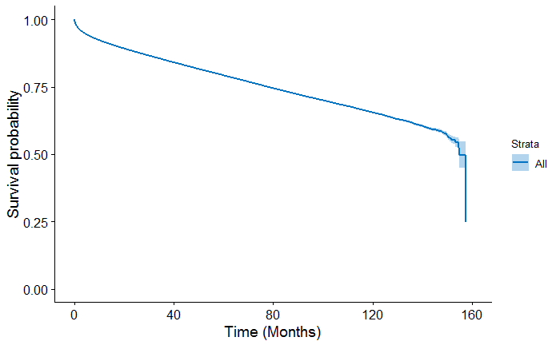

```r
uni_var(test_var = "All", data_imp = data)
```

### Facility Type

```
_________________________________________________

## FACILITY_TYPE_F
_________________________________________________
Call: survfit(formula = Surv(DX_LASTCONTACT_DEATH_MONTHS, PUF_VITAL_STATUS ==
    0) ~ FACILITY_TYPE_F, data = data)

   30805 observations deleted due to missingness
                                                  n events median 0.95LCL 0.95UCL
FACILITY_TYPE_F=Academic/Research Program     97390  18152    157     155      NA
FACILITY_TYPE_F=Community Cancer Program      13313   4305    110     103     114
FACILITY_TYPE_F=Comprehensive Comm Ca Program 84250  23503    140     137     143
FACILITY_TYPE_F=Integrated Network Ca Program 29993   7136    155     153      NA

Call: survfit(formula = Surv(DX_LASTCONTACT_DEATH_MONTHS, PUF_VITAL_STATUS ==
    0) ~ FACILITY_TYPE_F, data = data)

30805 observations deleted due to missingness
                FACILITY_TYPE_F=Academic/Research Program
 time n.risk n.event survival  std.err lower 95% CI upper 95% CI
   12  84658    6553    0.931 0.000828        0.929        0.932
   24  74032    2591    0.901 0.000986        0.899        0.903
   36  61928    2027    0.874 0.001120        0.872        0.876
   48  50793    1731    0.848 0.001255        0.845        0.850
   60  40410    1367    0.823 0.001390        0.820        0.825
  120   6994    3530    0.693 0.002540        0.688        0.698

                FACILITY_TYPE_F=Community Cancer Program
 time n.risk n.event survival std.err lower 95% CI upper 95% CI
   12  10134    1708    0.862 0.00310        0.856        0.868
   24   8502     650    0.804 0.00364        0.797        0.811
   36   6864     483    0.755 0.00404        0.747        0.763
   48   5392     380    0.710 0.00442        0.701        0.718
   60   4175     315    0.664 0.00483        0.655        0.674
  120    585     710    0.473 0.00779        0.458        0.488

                FACILITY_TYPE_F=Comprehensive Comm Ca Program
 time n.risk n.event survival std.err lower 95% CI upper 95% CI
   12  68873    9114    0.887 0.00112        0.885        0.889
   24  59221    3441    0.841 0.00131        0.838        0.843
```

[output cut: 29 more lines]

```
FACILITY_TYPE_FComprehensive Comm Ca Program 0.485169  1.624450 0.009883 49.09   <2e-16 ***
FACILITY_TYPE_FIntegrated Network Ca Program 0.284847  1.329558 0.013972 20.39   <2e-16 ***
---
Signif. codes:  0 *** 0.001 ** 0.01 * 0.05 . 0.1   1

                                             exp(coef) exp(-coef) lower .95 upper .95
FACILITY_TYPE_FCommunity Cancer Program          2.086     0.4795     2.018     2.156
FACILITY_TYPE_FComprehensive Comm Ca Program     1.624     0.6156     1.593     1.656
FACILITY_TYPE_FIntegrated Network Ca Program     1.330     0.7521     1.294     1.366

Concordance= 0.568  (se = 0.001 )
Rsquare= 0.014   (max possible= 0.996 )
Likelihood ratio test= 3259  on 3 df,   p=<2e-16
Wald test            = 3245  on 3 df,   p=<2e-16
Score (logrank) test = 3323  on 3 df,   p=<2e-16
```

```
Removed 1 rows containing missing values (geom_errorbar).
```

```
## Unadjusted Kaplan Meier Overall Survival Curve for:  FACILITY_TYPE_F
```

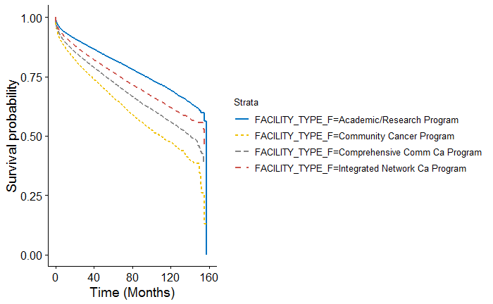

```r
uni_var(test_var = "FACILITY_TYPE_F", data_imp = data)
```

### Age Group

```
_________________________________________________

## AGE_F
_________________________________________________
Call: survfit(formula = Surv(DX_LASTCONTACT_DEATH_MONTHS, PUF_VITAL_STATUS ==
    0) ~ AGE_F, data = data)

   398 observations deleted due to missingness
                   n events median 0.95LCL 0.95UCL
AGE_F=(0,54]   90713   5203     NA      NA      NA
AGE_F=(54,64]  54517   6697    157      NA      NA
AGE_F=(64,74]  50605  11721    146   141.9   148.1
AGE_F=(74,100] 59518  30665     58    57.1    58.8

Call: survfit(formula = Surv(DX_LASTCONTACT_DEATH_MONTHS, PUF_VITAL_STATUS ==
    0) ~ AGE_F, data = data)

398 observations deleted due to missingness
                AGE_F=(0,54]
 time n.risk n.event survival  std.err lower 95% CI upper 95% CI
   12  81344    1746    0.980 0.000476        0.979        0.981
   24  72591     754    0.970 0.000584        0.969        0.972
   36  62166     574    0.962 0.000673        0.961        0.963
   48  52300     447    0.955 0.000756        0.953        0.956
   60  42633     411    0.946 0.000852        0.945        0.948
  120   8266    1151    0.899 0.001712        0.896        0.902

                AGE_F=(54,64]
 time n.risk n.event survival  std.err lower 95% CI upper 95% CI
   12  48189    2350    0.955 0.000906        0.953        0.957
   24  42468    1007    0.934 0.001099        0.932        0.936
   36  35920     762    0.916 0.001257        0.914        0.919
   48  29774     592    0.900 0.001405        0.897        0.903
   60  23987     505    0.883 0.001565        0.880        0.886
  120   4229    1352    0.788 0.003092        0.782        0.794

                AGE_F=(64,74]
 time n.risk n.event survival std.err lower 95% CI upper 95% CI
   12  43096    4094    0.916 0.00126        0.913        0.918
   24  37316    1683    0.879 0.00150        0.876        0.881
```

[output cut: 29 more lines]

```
AGE_F(64,74]   1.51945   4.56973  0.01667  91.17   <2e-16 ***
AGE_F(74,100]  2.58851  13.30993  0.01506 171.87   <2e-16 ***
---
Signif. codes:  0 *** 0.001 ** 0.01 * 0.05 . 0.1   1

              exp(coef) exp(-coef) lower .95 upper .95
AGE_F(54,64]       2.24    0.44633     2.161     2.323
AGE_F(64,74]       4.57    0.21883     4.423     4.721
AGE_F(74,100]     13.31    0.07513    12.923    13.709

Concordance= 0.748  (se = 0.001 )
Rsquare= 0.177   (max possible= 0.994 )
Likelihood ratio test= 49725  on 3 df,   p=<2e-16
Wald test            = 42300  on 3 df,   p=<2e-16
Score (logrank) test = 59786  on 3 df,   p=<2e-16
```

```
Removed 1 rows containing missing values (geom_errorbar).
```

```
## Unadjusted Kaplan Meier Overall Survival Curve for:  AGE_F
```

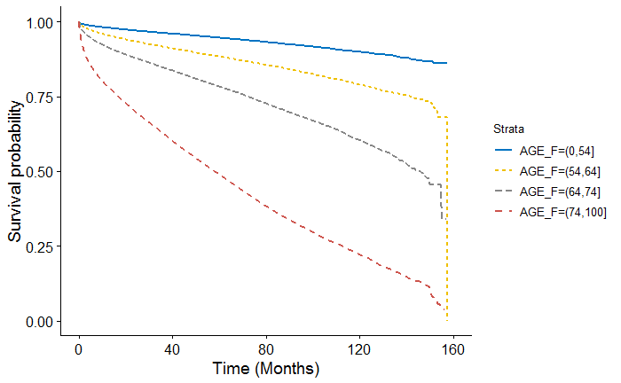

```r
uni_var(test_var = "AGE_F", data_imp = data)
```

### Gender

```
_________________________________________________

## SEX_F
_________________________________________________
Call: survfit(formula = Surv(DX_LASTCONTACT_DEATH_MONTHS, PUF_VITAL_STATUS ==
    0) ~ SEX_F, data = data)

                  n events median 0.95LCL 0.95UCL
SEX_F=Male    82812  19103    155     151      NA
SEX_F=Female 172939  35222     NA     155      NA

Call: survfit(formula = Surv(DX_LASTCONTACT_DEATH_MONTHS, PUF_VITAL_STATUS ==
    0) ~ SEX_F, data = data)

                SEX_F=Male
 time n.risk n.event survival std.err lower 95% CI upper 95% CI
   12  68712    7586    0.904 0.00105        0.902        0.906
   24  59271    2807    0.866 0.00123        0.863        0.868
   36  49126    2078    0.833 0.00138        0.830        0.836
   48  39948    1715    0.802 0.00152        0.799        0.805
   60  31646    1375    0.771 0.00167        0.768        0.775
  120   5231    3246    0.631 0.00287        0.626        0.637

                SEX_F=Female
 time n.risk n.event survival  std.err lower 95% CI upper 95% CI
   12 147385   12809    0.923 0.000656        0.922        0.924
   24 128448    5153    0.889 0.000782        0.888        0.891
   36 107388    3988    0.859 0.000886        0.858        0.861
   48  88102    3292    0.831 0.000987        0.829        0.833
   60  70074    2663    0.803 0.001090        0.801        0.806
  120  11830    6740    0.666 0.001944        0.663        0.670





## Univariable Cox Proportional Hazard Model for:  SEX_F

Call:
coxph(formula = Surv(DX_LASTCONTACT_DEATH_MONTHS, PUF_VITAL_STATUS ==
    0) ~ SEX_F, data = data)

  n= 255751, number of events= 54325

                 coef exp(coef)  se(coef)      z Pr(>|z|)
SEX_FFemale -0.160944  0.851340  0.008986 -17.91   <2e-16 ***
---
Signif. codes:  0 *** 0.001 ** 0.01 * 0.05 . 0.1   1

            exp(coef) exp(-coef) lower .95 upper .95
SEX_FFemale    0.8513      1.175    0.8365    0.8665

Concordance= 0.52  (se = 0.001 )
Rsquare= 0.001   (max possible= 0.994 )
Likelihood ratio test= 315.4  on 1 df,   p=<2e-16
Wald test            = 320.8  on 1 df,   p=<2e-16
Score (logrank) test = 321.5  on 1 df,   p=<2e-16
```

```
Removed 1 rows containing missing values (geom_errorbar).
```

```
## Unadjusted Kaplan Meier Overall Survival Curve for:  SEX_F
```

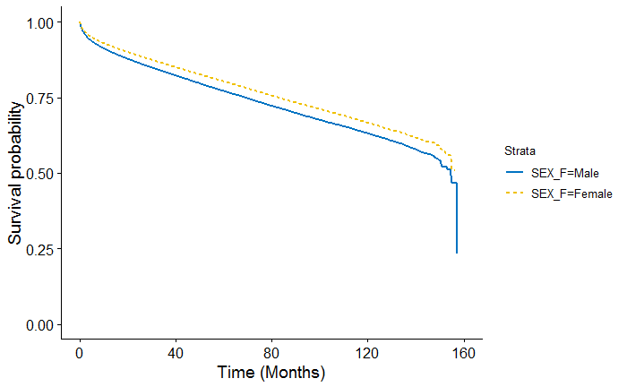

```r
uni_var(test_var = "SEX_F", data_imp = data)
```

### RACE_F

```
_________________________________________________

## RACE_F
_________________________________________________
Call: survfit(formula = Surv(DX_LASTCONTACT_DEATH_MONTHS, PUF_VITAL_STATUS ==
    0) ~ RACE_F, data = data)

                      n events median 0.95LCL 0.95UCL
RACE_F=White     211385  45612    155     155      NA
RACE_F=Black      28267   6507     NA      NA      NA
RACE_F=Other/Unk   8150   1017     NA      NA      NA
RACE_F=Asian       7949   1189     NA      NA      NA

Call: survfit(formula = Surv(DX_LASTCONTACT_DEATH_MONTHS, PUF_VITAL_STATUS ==
    0) ~ RACE_F, data = data)

                RACE_F=White
 time n.risk n.event survival  std.err lower 95% CI upper 95% CI
   12 179178   16928    0.917 0.000614        0.915        0.918
   24 155871    6646    0.881 0.000728        0.880        0.883
   36 130093    5116    0.850 0.000822        0.849        0.852
   48 106618    4187    0.821 0.000912        0.819        0.822
   60  84844    3423    0.792 0.001005        0.790        0.794
  120  14498    8557    0.651 0.001759        0.648        0.655

                RACE_F=Black
 time n.risk n.event survival std.err lower 95% CI upper 95% CI
   12  23434    2559    0.905 0.00178        0.902        0.909
   24  20160     987    0.865 0.00211        0.861        0.870
   36  16712     738    0.831 0.00237        0.827        0.836
   48  13560     617    0.798 0.00263        0.793        0.803
   60  10612     463    0.768 0.00288        0.762        0.773
  120   1548    1066    0.626 0.00513        0.616        0.636

                RACE_F=Other/Unk
 time n.risk n.event survival std.err lower 95% CI upper 95% CI
   12   6859     405    0.947 0.00256        0.942        0.952
   24   6004     143    0.926 0.00304        0.920        0.932
   36   5053      91    0.911 0.00338        0.905        0.918
   48   4207      82    0.895 0.00375        0.888        0.903
```

[output cut: 26 more lines]

```
RACE_FOther/Unk -0.55272   0.57538  0.03171 -17.433   <2e-16 ***
RACE_FAsian     -0.31551   0.72942  0.02938 -10.740   <2e-16 ***
---
Signif. codes:  0 *** 0.001 ** 0.01 * 0.05 . 0.1   1

                exp(coef) exp(-coef) lower .95 upper .95
RACE_FBlack        1.1182     0.8943    1.0895    1.1476
RACE_FOther/Unk    0.5754     1.7380    0.5407    0.6123
RACE_FAsian        0.7294     1.3710    0.6886    0.7727

Concordance= 0.516  (se = 0.001 )
Rsquare= 0.002   (max possible= 0.994 )
Likelihood ratio test= 582.3  on 3 df,   p=<2e-16
Wald test            = 509.4  on 3 df,   p=<2e-16
Score (logrank) test = 519.4  on 3 df,   p=<2e-16
```

```
Removed 1 rows containing missing values (geom_errorbar).
```

```
## Unadjusted Kaplan Meier Overall Survival Curve for:  RACE_F
```

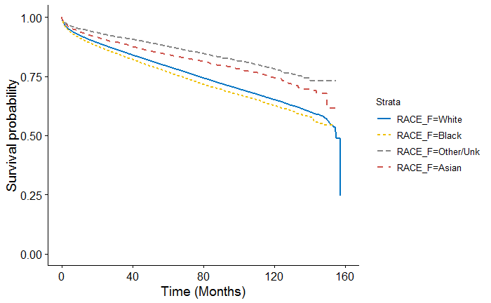

```r
uni_var(test_var = "RACE_F", data_imp = data)
```

### Insurance Status

```
_________________________________________________

## INSURANCE_F
_________________________________________________
Call: survfit(formula = Surv(DX_LASTCONTACT_DEATH_MONTHS, PUF_VITAL_STATUS ==
    0) ~ INSURANCE_F, data = data)

                                  n events median 0.95LCL 0.95UCL
INSURANCE_F=Private          114589  10189  157.3   157.3      NA
INSURANCE_F=None              10339   1207     NA      NA      NA
INSURANCE_F=Medicaid          16908   2415     NA   152.2      NA
INSURANCE_F=Medicare         104534  38954   95.4    93.9    96.6
INSURANCE_F=Other Government   3326    463  153.1   153.1      NA
INSURANCE_F=Unknown            6055   1097     NA      NA      NA

Call: survfit(formula = Surv(DX_LASTCONTACT_DEATH_MONTHS, PUF_VITAL_STATUS ==
    0) ~ INSURANCE_F, data = data)

                INSURANCE_F=Private
 time n.risk n.event survival  std.err lower 95% CI upper 95% CI
   12 102661    3521    0.968 0.000530        0.967        0.969
   24  91656    1477    0.954 0.000643        0.952        0.955
   36  78472    1106    0.941 0.000734        0.940        0.943
   48  65825     912    0.929 0.000824        0.928        0.931
   60  53697     787    0.917 0.000921        0.915        0.919
  120  10138    2157    0.849 0.001779        0.846        0.853

                INSURANCE_F=None
 time n.risk n.event survival std.err lower 95% CI upper 95% CI
   12   8442     492    0.948 0.00227        0.944        0.953
   24   7285     169    0.928 0.00269        0.923        0.934
   36   6070     146    0.908 0.00311        0.902        0.914
   48   4910     102    0.891 0.00347        0.885        0.898
   60   3781      86    0.874 0.00388        0.866        0.882
  120    590     194    0.783 0.00777        0.768        0.799

                INSURANCE_F=Medicaid
 time n.risk n.event survival std.err lower 95% CI upper 95% CI
   12  14285     972    0.939 0.00188        0.936        0.943
   24  12161     358    0.914 0.00225        0.910        0.919
```

[output cut: 50 more lines]

```
---
Signif. codes:  0 *** 0.001 ** 0.01 * 0.05 . 0.1   1

                            exp(coef) exp(-coef) lower .95 upper .95
INSURANCE_FNone                 1.550     0.6452     1.460     1.645
INSURANCE_FMedicaid             1.860     0.5376     1.779     1.945
INSURANCE_FMedicare             5.255     0.1903     5.142     5.371
INSURANCE_FOther Government     1.812     0.5520     1.651     1.989
INSURANCE_FUnknown              2.160     0.4630     2.030     2.299

Concordance= 0.683  (se = 0.001 )
Rsquare= 0.108   (max possible= 0.994 )
Likelihood ratio test= 29176  on 5 df,   p=<2e-16
Wald test            = 24520  on 5 df,   p=<2e-16
Score (logrank) test = 29879  on 5 df,   p=<2e-16
```

```
Removed 1 rows containing missing values (geom_errorbar).
```

```
## Unadjusted Kaplan Meier Overall Survival Curve for:  INSURANCE_F
```

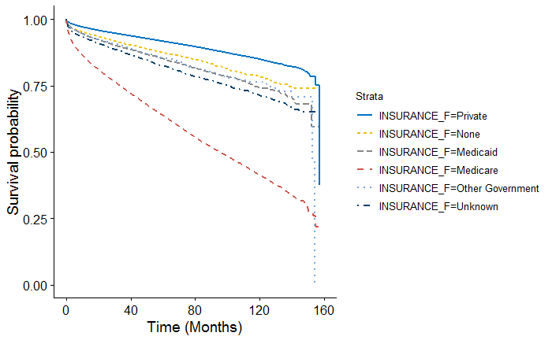

```r
uni_var(test_var = "INSURANCE_F", data_imp = data)
```

### Income

```
_________________________________________________

## INCOME_F
_________________________________________________
Call: survfit(formula = Surv(DX_LASTCONTACT_DEATH_MONTHS, PUF_VITAL_STATUS ==
    0) ~ INCOME_F, data = data)

   2381 observations deleted due to missingness
                           n events median 0.95LCL 0.95UCL
INCOME_F=Less than 38k 42251  10255    153     151      NA
INCOME_F=38k to 47k    57872  13136    154     152      NA
INCOME_F=48k to 63k    69013  14327    157      NA      NA
INCOME_F=Over 63k      84234  15609     NA     155      NA

Call: survfit(formula = Surv(DX_LASTCONTACT_DEATH_MONTHS, PUF_VITAL_STATUS ==
    0) ~ INCOME_F, data = data)

2381 observations deleted due to missingness
                INCOME_F=Less than 38k
 time n.risk n.event survival std.err lower 95% CI upper 95% CI
   12  35137    3942    0.903 0.00147        0.900        0.906
   24  30243    1500    0.862 0.00174        0.859        0.866
   36  25223    1143    0.827 0.00195        0.824        0.831
   48  20603     972    0.793 0.00216        0.789        0.797
   60  16320     702    0.763 0.00235        0.759        0.768
  120   2678    1844    0.612 0.00404        0.604        0.620

                INCOME_F=38k to 47k
 time n.risk n.event survival std.err lower 95% CI upper 95% CI
   12  48497    4879    0.912 0.00120        0.910        0.914
   24  42021    1922    0.874 0.00143        0.872        0.877
   36  35025    1466    0.842 0.00161        0.838        0.845
   48  28738    1167    0.811 0.00178        0.808        0.815
   60  22889    1004    0.780 0.00197        0.776        0.784
  120   3908    2466    0.633 0.00341        0.626        0.640

                INCOME_F=48k to 63k
 time n.risk n.event survival std.err lower 95% CI upper 95% CI
   12  58645    5252    0.921 0.00105        0.919        0.923
   24  50964    2132    0.886 0.00125        0.883        0.888
```

[output cut: 29 more lines]

```
INCOME_F48k to 63k -0.18229   0.83336  0.01294 -14.093   <2e-16 ***
INCOME_FOver 63k   -0.30946   0.73384  0.01271 -24.345   <2e-16 ***
---
Signif. codes:  0 *** 0.001 ** 0.01 * 0.05 . 0.1   1

                   exp(coef) exp(-coef) lower .95 upper .95
INCOME_F38k to 47k    0.9209      1.086    0.8974    0.9450
INCOME_F48k to 63k    0.8334      1.200    0.8125    0.8548
INCOME_FOver 63k      0.7338      1.363    0.7158    0.7524

Concordance= 0.532  (se = 0.001 )
Rsquare= 0.003   (max possible= 0.993 )
Likelihood ratio test= 697.8  on 3 df,   p=<2e-16
Wald test            = 697.4  on 3 df,   p=<2e-16
Score (logrank) test = 700.9  on 3 df,   p=<2e-16
```

```
Removed 1 rows containing missing values (geom_errorbar).
```

```
## Unadjusted Kaplan Meier Overall Survival Curve for:  INCOME_F
```

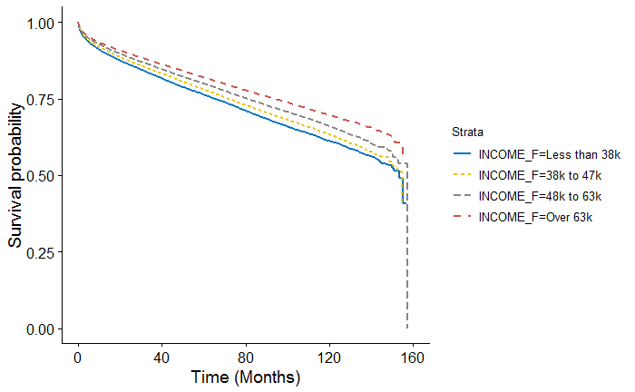

```r
uni_var(test_var = "INCOME_F", data_imp = data)
```

### Education

```
_________________________________________________

## EDUCATION_F
_________________________________________________
Call: survfit(formula = Surv(DX_LASTCONTACT_DEATH_MONTHS, PUF_VITAL_STATUS ==
    0) ~ EDUCATION_F, data = data)

   2267 observations deleted due to missingness
                             n events median 0.95LCL 0.95UCL
EDUCATION_F=21% or more  42552   9551    155     151      NA
EDUCATION_F=13 - 20.9%   63621  14214    157     152      NA
EDUCATION_F=7 - 12.9%    82041  17438     NA     154      NA
EDUCATION_F=Less than 7% 65270  12151     NA     155      NA

Call: survfit(formula = Surv(DX_LASTCONTACT_DEATH_MONTHS, PUF_VITAL_STATUS ==
    0) ~ EDUCATION_F, data = data)

2267 observations deleted due to missingness
                EDUCATION_F=21% or more
 time n.risk n.event survival std.err lower 95% CI upper 95% CI
   12  35269    3763    0.907 0.00144        0.904        0.910
   24  30427    1397    0.870 0.00170        0.866        0.873
   36  25276    1069    0.837 0.00191        0.833        0.841
   48  20613     905    0.804 0.00212        0.800        0.808
   60  16276     653    0.776 0.00231        0.772        0.781
  120   2513    1615    0.636 0.00408        0.628        0.644

                EDUCATION_F=13 - 20.9%
 time n.risk n.event survival std.err lower 95% CI upper 95% CI
   12  53348    5347    0.912 0.00115        0.910        0.914
   24  46128    2135    0.874 0.00136        0.871        0.877
   36  38341    1625    0.841 0.00154        0.838        0.844
   48  31300    1262    0.811 0.00170        0.808        0.814
   60  24794    1026    0.782 0.00187        0.778        0.786
  120   4124    2605    0.640 0.00323        0.634        0.646

                EDUCATION_F=7 - 12.9%
 time n.risk n.event survival  std.err lower 95% CI upper 95% CI
   12  69616    6489    0.918 0.000979        0.916        0.920
   24  60562    2500    0.883 0.001159        0.881        0.886
```

[output cut: 29 more lines]

```
EDUCATION_F7 - 12.9%    -0.09288   0.91130  0.01273  -7.296 2.96e-13 ***
EDUCATION_FLess than 7% -0.25211   0.77716  0.01368 -18.434  < 2e-16 ***
---
Signif. codes:  0 *** 0.001 ** 0.01 * 0.05 . 0.1   1

                        exp(coef) exp(-coef) lower .95 upper .95
EDUCATION_F13 - 20.9%      0.9779      1.023    0.9528    1.0036
EDUCATION_F7 - 12.9%       0.9113      1.097    0.8888    0.9343
EDUCATION_FLess than 7%    0.7772      1.287    0.7566    0.7983

Concordance= 0.527  (se = 0.001 )
Rsquare= 0.002   (max possible= 0.993 )
Likelihood ratio test= 472.4  on 3 df,   p=<2e-16
Wald test            = 461  on 3 df,   p=<2e-16
Score (logrank) test = 462.7  on 3 df,   p=<2e-16
```

```
Removed 1 rows containing missing values (geom_errorbar).
```

```
## Unadjusted Kaplan Meier Overall Survival Curve for:  EDUCATION_F
```

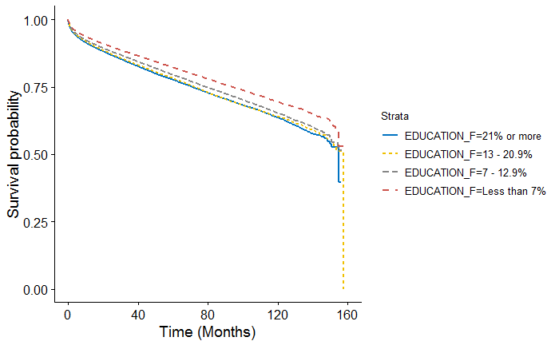

```r
uni_var(test_var = "EDUCATION_F", data_imp = data)
```

### Urban/Rural

```
_________________________________________________

## U_R_F
_________________________________________________
Call: survfit(formula = Surv(DX_LASTCONTACT_DEATH_MONTHS, PUF_VITAL_STATUS ==
    0) ~ U_R_F, data = data)

   7745 observations deleted due to missingness
                 n events median 0.95LCL 0.95UCL
U_R_F=Metro 211176  44486    157     155      NA
U_R_F=Urban  32846   6903    155     152      NA
U_R_F=Rural   3984    921    149     139      NA

Call: survfit(formula = Surv(DX_LASTCONTACT_DEATH_MONTHS, PUF_VITAL_STATUS ==
    0) ~ U_R_F, data = data)

7745 observations deleted due to missingness
                U_R_F=Metro
 time n.risk n.event survival  std.err lower 95% CI upper 95% CI
   12 178984   16650    0.918 0.000610        0.917        0.919
   24 155653    6539    0.883 0.000725        0.881        0.884
   36 129681    5032    0.852 0.000819        0.851        0.854
   48 106063    4148    0.823 0.000910        0.821        0.824
   60  84207    3326    0.794 0.001003        0.792        0.796
  120  13951    8093    0.658 0.001769        0.655        0.662

                U_R_F=Urban
 time n.risk n.event survival std.err lower 95% CI upper 95% CI
   12  27711    2542    0.919 0.00154        0.916        0.922
   24  24022     997    0.885 0.00183        0.881        0.888
   36  20184     728    0.856 0.00206        0.852        0.860
   48  16578     604    0.828 0.00228        0.824        0.833
   60  13210     495    0.801 0.00251        0.796        0.806
  120   2409    1404    0.655 0.00444        0.647        0.664

                U_R_F=Rural
 time n.risk n.event survival std.err lower 95% CI upper 95% CI
   12   3359     331    0.913 0.00456        0.904        0.922
   24   2907     128    0.877 0.00540        0.866        0.888
   36   2432      99    0.845 0.00609        0.833        0.857
```

[output cut: 17 more lines]

```
                coef exp(coef)  se(coef)      z Pr(>|z|)
U_R_FUrban -0.009494  0.990551  0.012936 -0.734  0.46301
U_R_FRural  0.089969  1.094140  0.033291  2.703  0.00688 **
---
Signif. codes:  0 *** 0.001 ** 0.01 * 0.05 . 0.1   1

           exp(coef) exp(-coef) lower .95 upper .95
U_R_FUrban    0.9906      1.010    0.9658     1.016
U_R_FRural    1.0941      0.914    1.0250     1.168

Concordance= 0.502  (se = 0.001 )
Rsquare= 0   (max possible= 0.993 )
Likelihood ratio test= 7.86  on 2 df,   p=0.02
Wald test            = 8.07  on 2 df,   p=0.02
Score (logrank) test = 8.08  on 2 df,   p=0.02
```

```
Removed 1 rows containing missing values (geom_errorbar).
```

```
## Unadjusted Kaplan Meier Overall Survival Curve for:  U_R_F
```

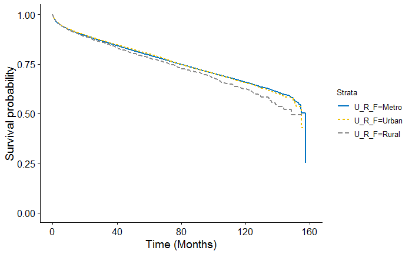

```r
uni_var(test_var = "U_R_F", data_imp = data)
```

### Comorbidities

```
_________________________________________________

## CDCC_TOTAL
_________________________________________________
Call: survfit(formula = Surv(DX_LASTCONTACT_DEATH_MONTHS, PUF_VITAL_STATUS ==
    0) ~ CDCC_TOTAL, data = data)

                  n events median 0.95LCL 0.95UCL
CDCC_TOTAL=0 195430  33578  157.3   155.0      NA
CDCC_TOTAL=1  40775  12271  126.3   124.0   129.2
CDCC_TOTAL=2  13034   5311   81.9    78.9    85.5
CDCC_TOTAL=3   6512   3165   57.6    54.8    60.7

Call: survfit(formula = Surv(DX_LASTCONTACT_DEATH_MONTHS, PUF_VITAL_STATUS ==
    0) ~ CDCC_TOTAL, data = data)

                CDCC_TOTAL=0
 time n.risk n.event survival  std.err lower 95% CI upper 95% CI
   12 168863   11474    0.939 0.000555        0.938        0.940
   24 148075    4935    0.910 0.000671        0.909        0.911
   36 124632    3818    0.885 0.000767        0.883        0.886
   48 103038    3181    0.860 0.000860        0.859        0.862
   60  82605    2634    0.836 0.000956        0.834        0.838
  120  14556    6875    0.712 0.001758        0.709        0.715

                CDCC_TOTAL=1
 time n.risk n.event survival std.err lower 95% CI upper 95% CI
   12  32926    4972    0.873 0.00168        0.870        0.876
   24  27968    1807    0.823 0.00196        0.819        0.827
   36  22694    1343    0.780 0.00217        0.776        0.785
   48  18029    1099    0.739 0.00239        0.734        0.744
   60  13944     862    0.700 0.00261        0.695        0.705
  120   1933    2036    0.520 0.00441        0.512        0.529

                CDCC_TOTAL=2
 time n.risk n.event survival std.err lower 95% CI upper 95% CI
   12   9799    2387    0.810 0.00350        0.803        0.817
   24   8109     732    0.747 0.00394        0.739        0.754
   36   6418     574    0.690 0.00430        0.681        0.698
   48   4935     478    0.633 0.00466        0.624        0.643
```

[output cut: 26 more lines]

```
CDCC_TOTAL2 1.09662   2.99403  0.01479 74.16   <2e-16 ***
CDCC_TOTAL3 1.40969   4.09470  0.01864 75.64   <2e-16 ***
---
Signif. codes:  0 *** 0.001 ** 0.01 * 0.05 . 0.1   1

            exp(coef) exp(-coef) lower .95 upper .95
CDCC_TOTAL1     1.994     0.5016     1.953     2.035
CDCC_TOTAL2     2.994     0.3340     2.908     3.082
CDCC_TOTAL3     4.095     0.2442     3.948     4.247

Concordance= 0.599  (se = 0.001 )
Rsquare= 0.039   (max possible= 0.994 )
Likelihood ratio test= 10219  on 3 df,   p=<2e-16
Wald test            = 11958  on 3 df,   p=<2e-16
Score (logrank) test = 13200  on 3 df,   p=<2e-16
```

```
Removed 1 rows containing missing values (geom_errorbar).
```

```
## Unadjusted Kaplan Meier Overall Survival Curve for:  CDCC_TOTAL
```

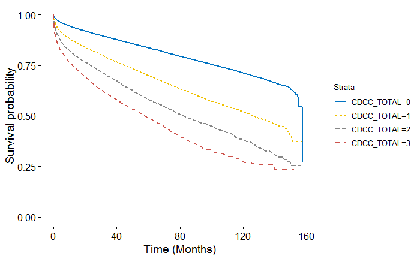

```r
uni_var(test_var = "CDCC_TOTAL", data_imp = data)
```

### Year

```
_________________________________________________

## YEAR_OF_DIAGNOSIS
_________________________________________________
Call: survfit(formula = Surv(DX_LASTCONTACT_DEATH_MONTHS, PUF_VITAL_STATUS ==
    0) ~ YEAR_OF_DIAGNOSIS, data = data)

                           n events median 0.95LCL 0.95UCL
YEAR_OF_DIAGNOSIS=2004 16445   5031    157     155      NA
YEAR_OF_DIAGNOSIS=2005 18449   5657     NA     144      NA
YEAR_OF_DIAGNOSIS=2006 19906   5693     NA      NA      NA
YEAR_OF_DIAGNOSIS=2007 21113   5770     NA      NA      NA
YEAR_OF_DIAGNOSIS=2008 22919   5675     NA      NA      NA
YEAR_OF_DIAGNOSIS=2009 24789   5778     NA      NA      NA
YEAR_OF_DIAGNOSIS=2010 24924   5232     NA      NA      NA
YEAR_OF_DIAGNOSIS=2011 25862   4698     NA      NA      NA
YEAR_OF_DIAGNOSIS=2012 26463   4177     NA      NA      NA
YEAR_OF_DIAGNOSIS=2013 27172   3625     NA      NA      NA
YEAR_OF_DIAGNOSIS=2014 27709   2989     NA      NA      NA

Call: survfit(formula = Surv(DX_LASTCONTACT_DEATH_MONTHS, PUF_VITAL_STATUS ==
    0) ~ YEAR_OF_DIAGNOSIS, data = data)

                YEAR_OF_DIAGNOSIS=2004
 time n.risk n.event survival std.err lower 95% CI upper 95% CI
   12  14162    1303    0.918 0.00217        0.914        0.922
   24  13241     500    0.885 0.00255        0.880        0.890
   36  12598     431    0.856 0.00282        0.851        0.862
   48  11951     408    0.828 0.00305        0.822        0.834
   60  11272     387    0.801 0.00325        0.795        0.807
  120   6830    1515    0.678 0.00402        0.670        0.686

                YEAR_OF_DIAGNOSIS=2005
 time n.risk n.event survival std.err lower 95% CI upper 95% CI
   12  16185    1517    0.916 0.00207        0.912        0.920
   24  15283     590    0.882 0.00241        0.877        0.887
   36  14555     496    0.853 0.00266        0.848        0.859
   48  13749     498    0.824 0.00288        0.818        0.829
   60  12932     430    0.798 0.00305        0.792        0.804
  120   7048    1822    0.668 0.00380        0.661        0.676
```

[output cut: 100 more lines]

```
YEAR_OF_DIAGNOSIS2006     1.065     0.9393     1.024     1.107
YEAR_OF_DIAGNOSIS2007     1.112     0.8989     1.070     1.157
YEAR_OF_DIAGNOSIS2008     1.096     0.9122     1.054     1.140
YEAR_OF_DIAGNOSIS2009     1.128     0.8868     1.084     1.173
YEAR_OF_DIAGNOSIS2010     1.132     0.8835     1.087     1.178
YEAR_OF_DIAGNOSIS2011     1.106     0.9039     1.061     1.153
YEAR_OF_DIAGNOSIS2012     1.119     0.8938     1.072     1.168
YEAR_OF_DIAGNOSIS2013     1.147     0.8721     1.096     1.199
YEAR_OF_DIAGNOSIS2014     1.180     0.8476     1.125     1.237

Concordance= 0.507  (se = 0.001 )
Rsquare= 0   (max possible= 0.994 )
Likelihood ratio test= 80.15  on 10 df,   p=5e-13
Wald test            = 79.24  on 10 df,   p=7e-13
Score (logrank) test = 79.29  on 10 df,   p=7e-13
```

```
Removed 1 rows containing missing values (geom_errorbar).
```

```
## Unadjusted Kaplan Meier Overall Survival Curve for:  YEAR_OF_DIAGNOSIS
```

```
This manual palette can handle a maximum of 10 values. You have supplied 11.Removed 1133 rows containing missing values (geom_path).This manual palette can handle a maximum of 10 values. You have supplied 11.Removed 1133 rows containing missing values (geom_path).
```

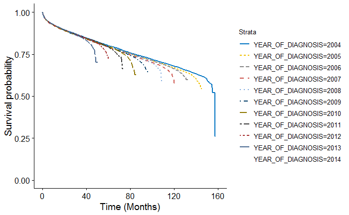

```r
uni_var(test_var = "YEAR_OF_DIAGNOSIS", data_imp = data)
```

### Histology

```
_________________________________________________

## HISTOLOGY_F_LIM
_________________________________________________
Call: survfit(formula = Surv(DX_LASTCONTACT_DEATH_MONTHS, PUF_VITAL_STATUS ==
    0) ~ HISTOLOGY_F_LIM, data = data)

                           n events median 0.95LCL 0.95UCL
HISTOLOGY_F_LIM=9530  157536  41313    147     143     149
HISTOLOGY_F_LIM=9560   39011   3081     NA      NA      NA
HISTOLOGY_F_LIM=Other  59204   9931     NA      NA      NA

Call: survfit(formula = Surv(DX_LASTCONTACT_DEATH_MONTHS, PUF_VITAL_STATUS ==
    0) ~ HISTOLOGY_F_LIM, data = data)

                HISTOLOGY_F_LIM=9530
 time n.risk n.event survival  std.err lower 95% CI upper 95% CI
   12 129658   15558    0.897 0.000786        0.895        0.898
   24 111076    6300    0.851 0.000932        0.849        0.853
   36  91488    4693    0.812 0.001047        0.810        0.814
   48  73977    3831    0.775 0.001158        0.773        0.778
   60  57989    3084    0.740 0.001269        0.738        0.742
  120   8957    7256    0.577 0.002175        0.572        0.581

                HISTOLOGY_F_LIM=9560
 time n.risk n.event survival  std.err lower 95% CI upper 95% CI
   12  35616     784    0.979 0.000735        0.978        0.981
   24  31713     434    0.967 0.000938        0.965        0.969
   36  27006     353    0.955 0.001110        0.953        0.957
   48  22580     317    0.943 0.001289        0.941        0.946
   60  18368     276    0.930 0.001479        0.928        0.933
  120   3582     819    0.855 0.003100        0.849        0.861

                HISTOLOGY_F_LIM=Other
 time n.risk n.event survival std.err lower 95% CI upper 95% CI
   12  50823    4053    0.929 0.00107        0.927        0.931
   24  44930    1226    0.906 0.00124        0.903        0.908
   36  38020    1020    0.884 0.00139        0.881        0.886
   48  31493     859    0.862 0.00154        0.859        0.865
   60  25363     678    0.842 0.00169        0.838        0.845
```

[output cut: 14 more lines]

```
                         coef exp(coef) se(coef)      z Pr(>|z|)
HISTOLOGY_F_LIM9560  -1.36443   0.25553  0.01868 -73.03   <2e-16 ***
HISTOLOGY_F_LIMOther -0.53591   0.58514  0.01118 -47.93   <2e-16 ***
---
Signif. codes:  0 *** 0.001 ** 0.01 * 0.05 . 0.1   1

                     exp(coef) exp(-coef) lower .95 upper .95
HISTOLOGY_F_LIM9560     0.2555      3.913    0.2463    0.2651
HISTOLOGY_F_LIMOther    0.5851      1.709    0.5725    0.5981

Concordance= 0.594  (se = 0.001 )
Rsquare= 0.035   (max possible= 0.994 )
Likelihood ratio test= 9005  on 2 df,   p=<2e-16
Wald test            = 6908  on 2 df,   p=<2e-16
Score (logrank) test = 7700  on 2 df,   p=<2e-16
```

```
Removed 1 rows containing missing values (geom_errorbar).
```

```
## Unadjusted Kaplan Meier Overall Survival Curve for:  HISTOLOGY_F_LIM
```

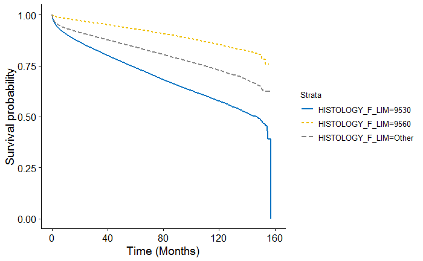

```r
uni_var(test_var = "HISTOLOGY_F_LIM", data_imp = data)
```

Note: histology code 9530 represents meningioma and 9560 represents neuroma.

### Tumor Size

```
_________________________________________________

## T_SIZE
_________________________________________________
Call: survfit(formula = Surv(DX_LASTCONTACT_DEATH_MONTHS, PUF_VITAL_STATUS ==
    0) ~ T_SIZE, data = data)

                             n events median 0.95LCL 0.95UCL
T_SIZE=< 1 cm            23660   4378     NA     153      NA
T_SIZE=No Tumor             97     15     NA      NA      NA
T_SIZE=Microscopic focus   134     22     NA      NA      NA
T_SIZE=1-2 cm            60920  12728     NA      NA      NA
T_SIZE=2-3 cm            43680   9408    154     152      NA
T_SIZE=3-4 cm            29104   6419     NA      NA      NA
T_SIZE=4-5 cm            19690   4394    157     150      NA
T_SIZE=5-6 cm            12322   2749    150     149      NA
T_SIZE=>6 cm             14072   3203    153     150      NA
T_SIZE=NA_unk            52072  11009     NA     155      NA

Call: survfit(formula = Surv(DX_LASTCONTACT_DEATH_MONTHS, PUF_VITAL_STATUS ==
    0) ~ T_SIZE, data = data)

                T_SIZE=< 1 cm
 time n.risk n.event survival std.err lower 95% CI upper 95% CI
   12  20113    1524    0.932 0.00168        0.929        0.936
   24  17280     741    0.896 0.00207        0.892        0.900
   36  14006     535    0.866 0.00238        0.861        0.871
   48  11144     398    0.839 0.00267        0.834        0.844
   60   8574     327    0.811 0.00298        0.806        0.817
  120   1201     793    0.668 0.00589        0.657        0.680

                T_SIZE=No Tumor
 time n.risk n.event survival std.err lower 95% CI upper 95% CI
   12     81       7    0.925  0.0272        0.873        0.980
   24     63       5    0.861  0.0376        0.790        0.938
   36     53       0    0.861  0.0376        0.790        0.938
   48     35       1    0.841  0.0416        0.764        0.927
   60     22       0    0.841  0.0416        0.764        0.927
  120      1       2    0.733  0.0824        0.588        0.913

```

[output cut: 98 more lines]

```
T_SIZENo Tumor              1.039     0.9625    0.6258     1.725
T_SIZEMicroscopic focus     0.858     1.1655    0.5644     1.304
T_SIZE1-2 cm                1.118     0.8943    1.0805     1.157
T_SIZE2-3 cm                1.123     0.8903    1.0837     1.164
T_SIZE3-4 cm                1.158     0.8634    1.1145     1.204
T_SIZE4-5 cm                1.174     0.8520    1.1256     1.224
T_SIZE5-6 cm                1.191     0.8397    1.1355     1.249
T_SIZE>6 cm                 1.188     0.8415    1.1355     1.244
T_SIZENA_unk                1.008     0.9925    0.9728     1.043

Concordance= 0.519  (se = 0.001 )
Rsquare= 0.001   (max possible= 0.994 )
Likelihood ratio test= 207.6  on 9 df,   p=<2e-16
Wald test            = 205.2  on 9 df,   p=<2e-16
Score (logrank) test = 205.5  on 9 df,   p=<2e-16
```

```
Removed 1 rows containing missing values (geom_errorbar).
```

```
## Unadjusted Kaplan Meier Overall Survival Curve for:  T_SIZE
```

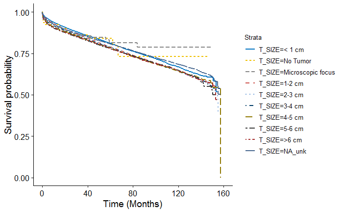

```r
uni_var(test_var = "T_SIZE", data_imp = data)
```

## Multivariable Cox Proportional Hazard Ratio for all patients

```r
model_one <- coxph(Surv(DX_LASTCONTACT_DEATH_MONTHS, PUF_VITAL_STATUS == 0)
                     ~ INSURANCE_F + AGE_F + SEX_F + RACE_F + INCOME_F + U_R_F + CDCC_TOTAL +
                      FACILITY_TYPE_F + EDUCATION_F + T_SIZE +  YEAR_OF_DIAGNOSIS +
                       RADIATION_YN,
                     data = data)
model_one %>% summary()
```

```
Call:
coxph(formula = Surv(DX_LASTCONTACT_DEATH_MONTHS, PUF_VITAL_STATUS ==
    0) ~ INSURANCE_F + AGE_F + SEX_F + RACE_F + INCOME_F + U_R_F +
    CDCC_TOTAL + FACILITY_TYPE_F + EDUCATION_F + T_SIZE + YEAR_OF_DIAGNOSIS +
    RADIATION_YN, data = data)

  n= 217793, number of events= 51032
   (37958 observations deleted due to missingness)

                                                   coef  exp(coef)   se(coef)       z Pr(>|z|)
INSURANCE_FNone                               0.4217681  1.5246550  0.0327908  12.862  < 2e-16 ***
INSURANCE_FMedicaid                           0.6247685  1.8678136  0.0248180  25.174  < 2e-16 ***
INSURANCE_FMedicare                           0.3814081  1.4643451  0.0152952  24.936  < 2e-16 ***
INSURANCE_FOther Government                   0.2851058  1.3299027  0.0495875   5.750 8.95e-09 ***
INSURANCE_FUnknown                            0.3144571  1.3695156  0.0337380   9.321  < 2e-16 ***
AGE_F(54,64]                                  0.6190750  1.8572093  0.0204411  30.286  < 2e-16 ***
AGE_F(64,74]                                  1.1039470  3.0160469  0.0214875  51.376  < 2e-16 ***
AGE_F(74,100]                                 2.1318241  8.4302302  0.0207590 102.694  < 2e-16 ***
SEX_FFemale                                  -0.2827428  0.7537137  0.0094066 -30.058  < 2e-16 ***
RACE_FBlack                                   0.1695666  1.1847913  0.0145877  11.624  < 2e-16 ***
RACE_FOther/Unk                              -0.2534361  0.7761293  0.0332861  -7.614 2.66e-14 ***
RACE_FAsian                                  -0.1748960  0.8395444  0.0307332  -5.691 1.26e-08 ***
INCOME_F38k to 47k                           -0.0604721  0.9413200  0.0146260  -4.135 3.56e-05 ***
INCOME_F48k to 63k                           -0.0996149  0.9051860  0.0157413  -6.328 2.48e-10 ***
INCOME_FOver 63k                             -0.1057482  0.8996512  0.0179671  -5.886 3.96e-09 ***
U_R_FUrban                                   -0.0371438  0.9635376  0.0139065  -2.671 0.007563 **
U_R_FRural                                   -0.0631602  0.9387931  0.0342173  -1.846 0.064913 .
CDCC_TOTAL1                                   0.3397174  1.4045506  0.0110005  30.882  < 2e-16 ***
CDCC_TOTAL2                                   0.5676308  1.7640826  0.0153264  37.036  < 2e-16 ***
CDCC_TOTAL3                                   0.8168684  2.2634008  0.0192820  42.364  < 2e-16 ***
FACILITY_TYPE_FCommunity Cancer Program       0.3076598  1.3602382  0.0175996  17.481  < 2e-16 ***
FACILITY_TYPE_FComprehensive Comm Ca Program  0.2073684  1.2304357  0.0102931  20.146  < 2e-16 ***
FACILITY_TYPE_FIntegrated Network Ca Program  0.1188693  1.1262227  0.0143551   8.281  < 2e-16 ***
EDUCATION_F13 - 20.9%                        -0.0002517  0.9997484  0.0143434  -0.018 0.986002
EDUCATION_F7 - 12.9%                         -0.0397707  0.9610097  0.0155939  -2.550 0.010760 *
EDUCATION_FLess than 7%                      -0.1286707  0.8792635  0.0185085  -6.952 3.60e-12 ***
T_SIZENo Tumor                                0.1461495  1.1573692  0.2677876   0.546 0.585226
T_SIZEMicroscopic focus                       0.2935310  1.3411548  0.2188430   1.341 0.179828
T_SIZE1-2 cm                                  0.0298906  1.0303418  0.0179397   1.666 0.095680 .
T_SIZE2-3 cm                                  0.0682402  1.0706224  0.0187865   3.632 0.000281 ***
```

[output cut: 59 more lines]

```
YEAR_OF_DIAGNOSIS2008                           1.0101     0.9900    0.9698    1.0521
YEAR_OF_DIAGNOSIS2009                           1.0304     0.9705    0.9891    1.0734
YEAR_OF_DIAGNOSIS2010                           1.0302     0.9707    0.9879    1.0743
YEAR_OF_DIAGNOSIS2011                           1.0132     0.9870    0.9704    1.0577
YEAR_OF_DIAGNOSIS2012                           1.0305     0.9704    0.9856    1.0774
YEAR_OF_DIAGNOSIS2013                           1.0610     0.9425    1.0129    1.1115
YEAR_OF_DIAGNOSIS2014                           1.0800     0.9259    1.0281    1.1345
RADIATION_YNUkn                                 0.9762     1.0244    0.8997    1.0593
RADIATION_YNYes                                 0.7963     1.2559    0.7712    0.8222

Concordance= 0.763  (se = 0.001 )
Rsquare= 0.197   (max possible= 0.996 )
Likelihood ratio test= 47810  on 47 df,   p=<2e-16
Wald test            = 41760  on 47 df,   p=<2e-16
Score (logrank) test = 55022  on 47 df,   p=<2e-16
```

Summary of Model

```r
model_one %>%
        tidy(., exponentiate = TRUE) %>%
        select(term, estimate, conf.low, conf.high, p.value) %>%
        rename(Variable = term,
               Hazard_Ratio = estimate) %>%
        tbl_df %>%
        print(n = nrow(.))
```

| Variable | Hazard_Ratio | conf.low | conf.high | p.value |
| --- | --- | --- | --- | --- |
| INSURANCE_FNone | 1.5246550 | 1.4297496 | 1.6258601 | 7.327734e-38 |
| INSURANCE_FMedicaid | 1.8678136 | 1.7791328 | 1.9609146 | 7.725984e-140 |
| INSURANCE_FMedicare | 1.4643451 | 1.4210984 | 1.5089080 | 2.996632e-137 |
| INSURANCE_FOther Government | 1.3299027 | 1.2067323 | 1.4656450 | 8.947966e-09 |
| INSURANCE_FUnknown | 1.3695156 | 1.2818851 | 1.4631366 | 1.157409e-20 |
| AGE_F(54,64] | 1.8572093 | 1.7842731 | 1.9331270 | 1.766847e-201 |
| AGE_F(64,74] | 3.0160469 | 2.8916647 | 3.1457794 | 0.000000e+00 |
| AGE_F(74,100] | 8.4302302 | 8.0941140 | 8.7803040 | 0.000000e+00 |
| SEX_FFemale | 0.7537137 | 0.7399450 | 0.7677385 | 1.725887e-198 |
| RACE_FBlack | 1.1847913 | 1.1513961 | 1.2191551 | 3.115034e-31 |

[output cut: 37 more lines]

Of note, radiation as part of primary treatment is included in this model and shows a significant survival advantage over those not receiving radiation.

## Limit to only those with radiation

```r
data_rad <- data %>%
    filter(RADIATION_YN == "Yes")
```

### Table of variables for all cases:

```r
p_table(data_rad,
        vars = c("FACILITY_TYPE_F", "AGE", "AGE_F",
                 "SEX_F", "RACE_F", "HISPANIC", "INSURANCE_F",
                 "INCOME_F", "EDUCATION_F", "U_R_F", "CROWFLY", "CDCC_TOTAL",
                 "PRIMARY_SITE", "HISTOLOGY_F_LIM", "BEHAVIOR",
                  "RX_SUMM_RADIATION_F", "PUF_30_DAY_MORT_CD_F",
                 "PUF_90_DAY_MORT_CD_F", "DX_LASTCONTACT_DEATH_MONTHS",
                  "SURG_RAD_SEQ", "T_SIZE", "SURGERY_YN", "RADIATION_YN", "CHEMO_YN"))
```

|  | level | Overall |
| --- | --- | --- |
| n |  | 30949 |
| FACILITY_TYPE_F (%) | Academic/Research Program | 14435 ( 46.6) |
|  | Community Cancer Program | 516 ( 1.7) |
|  | Comprehensive Comm Ca Program | 8234 ( 26.6) |
|  | Integrated Network Ca Program | 4466 ( 14.4) |
|  | NA | 3298 ( 10.7) |
| AGE (mean (sd)) |  | 58.01 (14.82) |
| AGE_F (%) | (0,54] | 12086 ( 39.1) |
|  | (54,64] | 8107 ( 26.2) |
|  | (64,74] | 6490 ( 21.0) |
|  | (74,100] | 4265 ( 13.8) |
|  | NA | 1 ( 0.0) |
| SEX_F (%) | Male | 11397 ( 36.8) |
|  | Female | 19552 ( 63.2) |
| RACE_F (%) | White | 25697 ( 83.0) |
|  | Black | 2998 ( 9.7) |
|  | Other/Unk | 1238 ( 4.0) |
|  | Asian | 1016 ( 3.3) |
| HISPANIC (%) | No | 27025 ( 87.3) |
|  | Yes | 1761 ( 5.7) |
|  | Unknown | 2163 ( 7.0) |
| INSURANCE_F (%) | Private | 16715 ( 54.0) |
|  | None | 870 ( 2.8) |
|  | Medicaid | 1787 ( 5.8) |
|  | Medicare | 10183 ( 32.9) |
|  | Other Government | 551 ( 1.8) |
|  | Unknown | 843 ( 2.7) |
| INCOME_F (%) | Less than 38k | 4706 ( 15.2) |
|  | 38k to 47k | 6659 ( 21.5) |
|  | 48k to 63k | 8574 ( 27.7) |

[output cut: 80 more lines]

### All

```
_________________________________________________

## All
_________________________________________________
Call: survfit(formula = Surv(DX_LASTCONTACT_DEATH_MONTHS, PUF_VITAL_STATUS ==
    0) ~ All, data = data_rad)

      n  events  median 0.95LCL 0.95UCL
  30949    4580      NA     155      NA

Call: survfit(formula = Surv(DX_LASTCONTACT_DEATH_MONTHS, PUF_VITAL_STATUS ==
    0) ~ All, data = data_rad)

 time n.risk n.event survival std.err lower 95% CI upper 95% CI
   12  28376    1010    0.966 0.00104        0.964        0.968
   24  25207     734    0.940 0.00138        0.938        0.943
   36  21403     561    0.918 0.00164        0.915        0.921
   48  17901     542    0.893 0.00192        0.889        0.897
   60  14555     404    0.871 0.00216        0.867        0.875
  120   2621    1196    0.744 0.00422        0.736        0.752




## Univariable Cox Proportional Hazard Model for:  All

[1] "Only one level, no Cox model performed"





## Unadjusted Kaplan Meier Overall Survival Curve for:  All
```

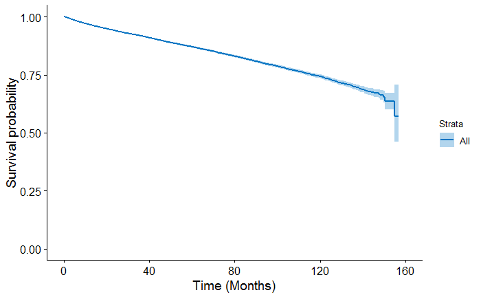

```r
uni_var(test_var = "All", data_imp = data_rad)
```

### Facility Type

```
_________________________________________________

## FACILITY_TYPE_F
_________________________________________________
Call: survfit(formula = Surv(DX_LASTCONTACT_DEATH_MONTHS, PUF_VITAL_STATUS ==
    0) ~ FACILITY_TYPE_F, data = data_rad)

   3298 observations deleted due to missingness
                                                  n events median 0.95LCL 0.95UCL
FACILITY_TYPE_F=Academic/Research Program     14435   2053     NA     155      NA
FACILITY_TYPE_F=Community Cancer Program        516    151    128     113      NA
FACILITY_TYPE_F=Comprehensive Comm Ca Program  8234   1527    150     150      NA
FACILITY_TYPE_F=Integrated Network Ca Program  4466    705     NA      NA      NA

Call: survfit(formula = Surv(DX_LASTCONTACT_DEATH_MONTHS, PUF_VITAL_STATUS ==
    0) ~ FACILITY_TYPE_F, data = data_rad)

3298 observations deleted due to missingness
                FACILITY_TYPE_F=Academic/Research Program
 time n.risk n.event survival std.err lower 95% CI upper 95% CI
   12  13258     416    0.970 0.00144        0.967        0.973
   24  11757     327    0.945 0.00195        0.942        0.949
   36   9970     245    0.924 0.00233        0.920        0.929
   48   8295     252    0.899 0.00276        0.893        0.904
   60   6771     186    0.877 0.00313        0.871        0.883
  120   1293     559    0.751 0.00607        0.739        0.763

                FACILITY_TYPE_F=Community Cancer Program
 time n.risk n.event survival std.err lower 95% CI upper 95% CI
   12    431      44    0.912  0.0127        0.887        0.937
   24    357      25    0.856  0.0162        0.825        0.888
   36    291      17    0.812  0.0185        0.776        0.849
   48    235      18    0.757  0.0213        0.716        0.800
   60    184      13    0.710  0.0236        0.665        0.758
  120     34      29    0.537  0.0357        0.472        0.612

                FACILITY_TYPE_F=Comprehensive Comm Ca Program
 time n.risk n.event survival std.err lower 95% CI upper 95% CI
   12   7495     385    0.952 0.00238        0.948        0.957
   24   6636     244    0.920 0.00306        0.914        0.926
```

[output cut: 29 more lines]

```
FACILITY_TYPE_FComprehensive Comm Ca Program 0.29415   1.34199  0.03380  8.702   <2e-16 ***
FACILITY_TYPE_FIntegrated Network Ca Program 0.07927   1.08250  0.04366  1.816   0.0694 .
---
Signif. codes:  0 *** 0.001 ** 0.01 * 0.05 . 0.1   1

                                             exp(coef) exp(-coef) lower .95 upper .95
FACILITY_TYPE_FCommunity Cancer Program          2.472     0.4045    2.0956     2.917
FACILITY_TYPE_FComprehensive Comm Ca Program     1.342     0.7452    1.2560     1.434
FACILITY_TYPE_FIntegrated Network Ca Program     1.083     0.9238    0.9937     1.179

Concordance= 0.546  (se = 0.004 )
Rsquare= 0.005   (max possible= 0.954 )
Likelihood ratio test= 148.2  on 3 df,   p=<2e-16
Wald test            = 167.3  on 3 df,   p=<2e-16
Score (logrank) test = 173.4  on 3 df,   p=<2e-16
```

```
Removed 1 rows containing missing values (geom_errorbar).
```

```
## Unadjusted Kaplan Meier Overall Survival Curve for:  FACILITY_TYPE_F
```

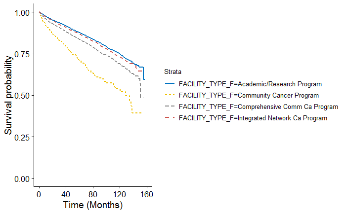

```r
uni_var(test_var = "FACILITY_TYPE_F", data_imp = data_rad)
```

### Age Group

```
_________________________________________________

## AGE_F
_________________________________________________
Call: survfit(formula = Surv(DX_LASTCONTACT_DEATH_MONTHS, PUF_VITAL_STATUS ==
    0) ~ AGE_F, data = data_rad)

   1 observation deleted due to missingness
                   n events median 0.95LCL 0.95UCL
AGE_F=(0,54]   12086    592     NA      NA      NA
AGE_F=(54,64]   8107    825     NA      NA      NA
AGE_F=(64,74]   6490   1263  149.7   144.7      NA
AGE_F=(74,100]  4265   1900   80.8    77.3    83.9

Call: survfit(formula = Surv(DX_LASTCONTACT_DEATH_MONTHS, PUF_VITAL_STATUS ==
    0) ~ AGE_F, data = data_rad)

1 observation deleted due to missingness
                AGE_F=(0,54]
 time n.risk n.event survival  std.err lower 95% CI upper 95% CI
   12  11295      76    0.993 0.000746        0.992        0.995
   24  10166      89    0.985 0.001137        0.983        0.988
   36   8773      82    0.977 0.001463        0.974        0.980
   48   7502      67    0.969 0.001755        0.965        0.972
   60   6183      67    0.959 0.002086        0.955        0.963
  120   1274     184    0.906 0.004598        0.897        0.916

                AGE_F=(54,64]
 time n.risk n.event survival std.err lower 95% CI upper 95% CI
   12   7572     155    0.980 0.00156        0.977        0.983
   24   6791     152    0.960 0.00224        0.956        0.964
   36   5816     105    0.944 0.00269        0.939        0.949
   48   4882      93    0.928 0.00313        0.922        0.934
   60   3990      71    0.913 0.00354        0.906        0.920
  120    687     224    0.818 0.00746        0.804        0.833

                AGE_F=(64,74]
 time n.risk n.event survival std.err lower 95% CI upper 95% CI
   12   5969     247    0.961 0.00244        0.956        0.966
   24   5266     188    0.929 0.00327        0.923        0.936
```

[output cut: 29 more lines]

```
AGE_F(64,74]   1.50016   4.48242  0.04985 30.10   <2e-16 ***
AGE_F(74,100]  2.51286  12.34012  0.04720 53.24   <2e-16 ***
---
Signif. codes:  0 *** 0.001 ** 0.01 * 0.05 . 0.1   1

              exp(coef) exp(-coef) lower .95 upper .95
AGE_F(54,64]      2.169    0.46113     1.951     2.410
AGE_F(64,74]      4.482    0.22309     4.065     4.942
AGE_F(74,100]    12.340    0.08104    11.250    13.536

Concordance= 0.742  (se = 0.004 )
Rsquare= 0.115   (max possible= 0.944 )
Likelihood ratio test= 3787  on 3 df,   p=<2e-16
Wald test            = 3647  on 3 df,   p=<2e-16
Score (logrank) test = 5034  on 3 df,   p=<2e-16
```

```
Removed 1 rows containing missing values (geom_errorbar).
```

```
## Unadjusted Kaplan Meier Overall Survival Curve for:  AGE_F
```

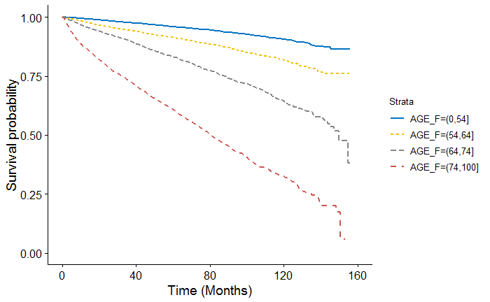

```r
uni_var(test_var = "AGE_F", data_imp = data_rad)
```

### Gender

```
_________________________________________________

## SEX_F
_________________________________________________
Call: survfit(formula = Surv(DX_LASTCONTACT_DEATH_MONTHS, PUF_VITAL_STATUS ==
    0) ~ SEX_F, data = data_rad)

                 n events median 0.95LCL 0.95UCL
SEX_F=Male   11397   1880    155     155      NA
SEX_F=Female 19552   2700     NA      NA      NA

Call: survfit(formula = Surv(DX_LASTCONTACT_DEATH_MONTHS, PUF_VITAL_STATUS ==
    0) ~ SEX_F, data = data_rad)

                SEX_F=Male
 time n.risk n.event survival std.err lower 95% CI upper 95% CI
   12  10342     428    0.961 0.00184        0.958        0.965
   24   9084     318    0.930 0.00246        0.926        0.935
   36   7656     229    0.905 0.00290        0.900        0.911
   48   6345     228    0.876 0.00339        0.869        0.883
   60   5121     171    0.850 0.00383        0.843        0.858
  120    897     455    0.719 0.00710        0.705        0.733

                SEX_F=Female
 time n.risk n.event survival std.err lower 95% CI upper 95% CI
   12  18034     582    0.969 0.00125        0.967        0.972
   24  16123     416    0.946 0.00166        0.943        0.950
   36  13747     332    0.925 0.00197        0.922        0.929
   48  11556     314    0.903 0.00231        0.898        0.907
   60   9434     233    0.883 0.00260        0.878        0.888
  120   1724     741    0.758 0.00524        0.748        0.768





## Univariable Cox Proportional Hazard Model for:  SEX_F

Call:
coxph(formula = Surv(DX_LASTCONTACT_DEATH_MONTHS, PUF_VITAL_STATUS ==
    0) ~ SEX_F, data = data_rad)

  n= 30949, number of events= 4580

                coef exp(coef) se(coef)      z Pr(>|z|)
SEX_FFemale -0.22897   0.79535  0.03004 -7.621 2.52e-14 ***
---
Signif. codes:  0 *** 0.001 ** 0.01 * 0.05 . 0.1   1

            exp(coef) exp(-coef) lower .95 upper .95
SEX_FFemale    0.7954      1.257    0.7499    0.8436

Concordance= 0.53  (se = 0.004 )
Rsquare= 0.002   (max possible= 0.944 )
Likelihood ratio test= 57.18  on 1 df,   p=4e-14
Wald test            = 58.08  on 1 df,   p=3e-14
Score (logrank) test = 58.33  on 1 df,   p=2e-14
```

```
Removed 1 rows containing missing values (geom_errorbar).
```

```
## Unadjusted Kaplan Meier Overall Survival Curve for:  SEX_F
```

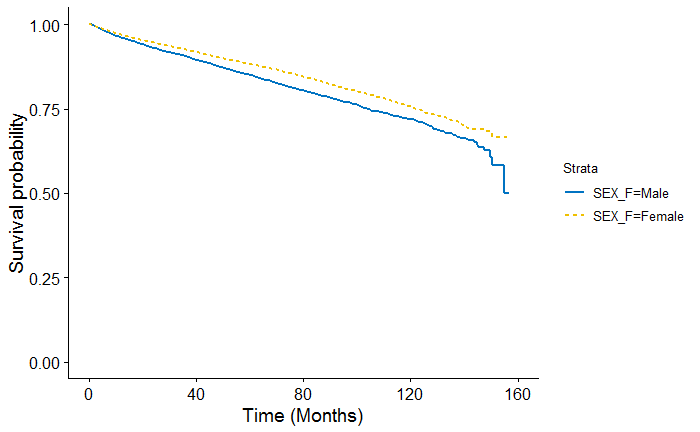

```r
uni_var(test_var = "SEX_F", data_imp = data_rad)
```

### RACE_F

```
_________________________________________________

## RACE_F
_________________________________________________
Call: survfit(formula = Surv(DX_LASTCONTACT_DEATH_MONTHS, PUF_VITAL_STATUS ==
    0) ~ RACE_F, data = data_rad)

                     n events median 0.95LCL 0.95UCL
RACE_F=White     25697   3848     NA     155      NA
RACE_F=Black      2998    513     NA      NA      NA
RACE_F=Other/Unk  1238    110     NA      NA      NA
RACE_F=Asian      1016    109     NA      NA      NA

Call: survfit(formula = Surv(DX_LASTCONTACT_DEATH_MONTHS, PUF_VITAL_STATUS ==
    0) ~ RACE_F, data = data_rad)

                RACE_F=White
 time n.risk n.event survival std.err lower 95% CI upper 95% CI
   12  23583     862    0.966 0.00115        0.963        0.968
   24  20978     610    0.940 0.00153        0.937        0.943
   36  17888     465    0.917 0.00181        0.914        0.921
   48  15014     434    0.893 0.00210        0.889        0.898
   60  12231     342    0.871 0.00236        0.867        0.876
  120   2221    1019    0.743 0.00461        0.734        0.752

                RACE_F=Black
 time n.risk n.event survival std.err lower 95% CI upper 95% CI
   12   2750     102    0.965 0.00338        0.959        0.972
   24   2419      87    0.934 0.00468        0.924        0.943
   36   2008      71    0.904 0.00570        0.893        0.915
   48   1632      83    0.863 0.00697        0.850        0.877
   60   1314      36    0.842 0.00764        0.827        0.857
  120    222     125    0.701 0.01437        0.673        0.729

                RACE_F=Other/Unk
 time n.risk n.event survival std.err lower 95% CI upper 95% CI
   12   1123      21    0.982 0.00389        0.974        0.990
   24   1007      20    0.964 0.00557        0.953        0.975
   36    854      14    0.949 0.00668        0.936        0.963
   48    719      12    0.935 0.00782        0.919        0.950
```

[output cut: 26 more lines]

```
RACE_FOther/Unk -0.48153   0.61783  0.09670 -4.979 6.38e-07 ***
RACE_FAsian     -0.26047   0.77069  0.09713 -2.682  0.00733 **
---
Signif. codes:  0 *** 0.001 ** 0.01 * 0.05 . 0.1   1

                exp(coef) exp(-coef) lower .95 upper .95
RACE_FBlack        1.2114     0.8255    1.1047    1.3283
RACE_FOther/Unk    0.6178     1.6186    0.5112    0.7468
RACE_FAsian        0.7707     1.2975    0.6371    0.9323

Concordance= 0.52  (se = 0.003 )
Rsquare= 0.002   (max possible= 0.944 )
Likelihood ratio test= 55.91  on 3 df,   p=4e-12
Wald test            = 51.7  on 3 df,   p=3e-11
Score (logrank) test = 52.46  on 3 df,   p=2e-11
```

```
Removed 1 rows containing missing values (geom_errorbar).
```

```
## Unadjusted Kaplan Meier Overall Survival Curve for:  RACE_F
```

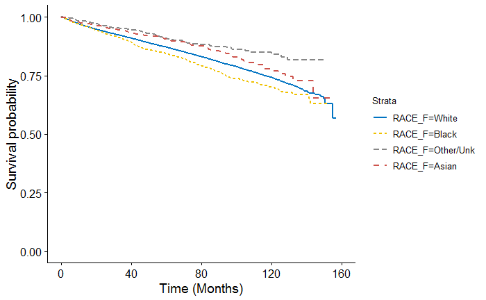

```r
uni_var(test_var = "RACE_F", data_imp = data_rad)
```

### Insurance Status

```
_________________________________________________

## INSURANCE_F
_________________________________________________
Call: survfit(formula = Surv(DX_LASTCONTACT_DEATH_MONTHS, PUF_VITAL_STATUS ==
    0) ~ INSURANCE_F, data = data_rad)

                                 n events median 0.95LCL 0.95UCL
INSURANCE_F=Private          16715   1219     NA     155      NA
INSURANCE_F=None               870     78     NA      NA      NA
INSURANCE_F=Medicaid          1787    216     NA      NA      NA
INSURANCE_F=Medicare         10183   2916    125     122     130
INSURANCE_F=Other Government   551     46     NA      NA      NA
INSURANCE_F=Unknown            843    105     NA      NA      NA

Call: survfit(formula = Surv(DX_LASTCONTACT_DEATH_MONTHS, PUF_VITAL_STATUS ==
    0) ~ INSURANCE_F, data = data_rad)

                INSURANCE_F=Private
 time n.risk n.event survival  std.err lower 95% CI upper 95% CI
   12  15662     212    0.987 0.000892        0.985        0.989
   24  14147     183    0.975 0.001244        0.973        0.977
   36  12194     164    0.963 0.001545        0.960        0.966
   48  10379     135    0.951 0.001818        0.948        0.955
   60   8556     115    0.940 0.002091        0.936        0.944
  120   1647     363    0.867 0.004504        0.858        0.876

                INSURANCE_F=None
 time n.risk n.event survival std.err lower 95% CI upper 95% CI
   12    800      15    0.982 0.00455        0.973        0.991
   24    700      16    0.962 0.00679        0.948        0.975
   36    591      10    0.947 0.00816        0.931        0.963
   48    499       8    0.933 0.00942        0.914        0.951
   60    407       6    0.920 0.01055        0.900        0.941
  120     57      21    0.811 0.02720        0.759        0.866

                INSURANCE_F=Medicaid
 time n.risk n.event survival std.err lower 95% CI upper 95% CI
   12   1650      41    0.977 0.00362        0.969        0.984
   24   1417      41    0.951 0.00531        0.940        0.961
```

[output cut: 50 more lines]

```
---
Signif. codes:  0 *** 0.001 ** 0.01 * 0.05 . 0.1   1

                            exp(coef) exp(-coef) lower .95 upper .95
INSURANCE_FNone                 1.377     0.7263    1.0951     1.731
INSURANCE_FMedicaid             1.948     0.5135    1.6851     2.251
INSURANCE_FMedicare             4.632     0.2159    4.3321     4.953
INSURANCE_FOther Government     1.262     0.7924    0.9402     1.694
INSURANCE_FUnknown              1.727     0.5789    1.4150     2.109

Concordance= 0.684  (se = 0.004 )
Rsquare= 0.072   (max possible= 0.944 )
Likelihood ratio test= 2322  on 5 df,   p=<2e-16
Wald test            = 2145  on 5 df,   p=<2e-16
Score (logrank) test = 2556  on 5 df,   p=<2e-16
```

```
Removed 1 rows containing missing values (geom_errorbar).
```

```
## Unadjusted Kaplan Meier Overall Survival Curve for:  INSURANCE_F
```

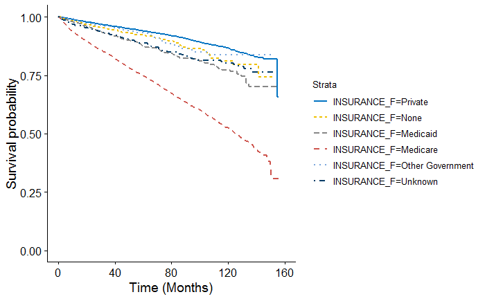

```r
uni_var(test_var = "INSURANCE_F", data_imp = data_rad)
```

### Income

```
_________________________________________________

## MED_INC_QUAR_12
_________________________________________________
Call: survfit(formula = Surv(DX_LASTCONTACT_DEATH_MONTHS, PUF_VITAL_STATUS ==
    0) ~ MED_INC_QUAR_12, data = data_rad)

   259 observations deleted due to missingness
                      n events median 0.95LCL 0.95UCL
MED_INC_QUAR_12=1  4706    855     NA      NA      NA
MED_INC_QUAR_12=2  6659   1079     NA      NA      NA
MED_INC_QUAR_12=3  8574   1212     NA      NA      NA
MED_INC_QUAR_12=4 10751   1348    155      NA      NA

Call: survfit(formula = Surv(DX_LASTCONTACT_DEATH_MONTHS, PUF_VITAL_STATUS ==
    0) ~ MED_INC_QUAR_12, data = data_rad)

259 observations deleted due to missingness
                MED_INC_QUAR_12=1
 time n.risk n.event survival std.err lower 95% CI upper 95% CI
   12   4283     180    0.961 0.00287        0.955        0.966
   24   3769     138    0.929 0.00387        0.921        0.936
   36   3202     109    0.900 0.00462        0.891        0.909
   48   2664     120    0.864 0.00550        0.853        0.874
   60   2179      73    0.838 0.00610        0.826        0.850
  120    399     214    0.696 0.01102        0.675        0.718

                MED_INC_QUAR_12=2
 time n.risk n.event survival std.err lower 95% CI upper 95% CI
   12   6099     240    0.963 0.00234        0.959        0.968
   24   5392     165    0.936 0.00308        0.930        0.942
   36   4584     125    0.913 0.00364        0.906        0.920
   48   3827     121    0.887 0.00424        0.878        0.895
   60   3088     100    0.861 0.00482        0.852        0.871
  120    565     285    0.722 0.00933        0.704        0.740

                MED_INC_QUAR_12=3
 time n.risk n.event survival std.err lower 95% CI upper 95% CI
   12   7902     261    0.969 0.00190        0.965        0.972
   24   7053     197    0.944 0.00256        0.939        0.949
```

[output cut: 29 more lines]

```
MED_INC_QUAR_123 -0.28066   0.75528  0.04466 -6.284  3.3e-10 ***
MED_INC_QUAR_124 -0.38829   0.67822  0.04372 -8.881  < 2e-16 ***
---
Signif. codes:  0 *** 0.001 ** 0.01 * 0.05 . 0.1   1

                 exp(coef) exp(-coef) lower .95 upper .95
MED_INC_QUAR_122    0.8844      1.131    0.8085    0.9675
MED_INC_QUAR_123    0.7553      1.324    0.6920    0.8244
MED_INC_QUAR_124    0.6782      1.474    0.6225    0.7389

Concordance= 0.539  (se = 0.005 )
Rsquare= 0.003   (max possible= 0.942 )
Likelihood ratio test= 92.69  on 3 df,   p=<2e-16
Wald test            = 94.19  on 3 df,   p=<2e-16
Score (logrank) test = 94.96  on 3 df,   p=<2e-16
```

```
Removed 1 rows containing missing values (geom_errorbar).
```

```
## Unadjusted Kaplan Meier Overall Survival Curve for:  MED_INC_QUAR_12
```

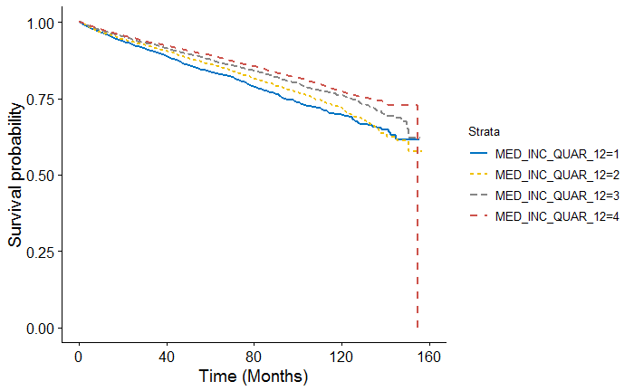

```r
uni_var(test_var = "MED_INC_QUAR_12", data_imp = data_rad)
```

### Education

```
_________________________________________________

## EDUCATION_F
_________________________________________________
Call: survfit(formula = Surv(DX_LASTCONTACT_DEATH_MONTHS, PUF_VITAL_STATUS ==
    0) ~ EDUCATION_F, data = data_rad)

   248 observations deleted due to missingness
                             n events median 0.95LCL 0.95UCL
EDUCATION_F=21% or more   4741    788     NA      NA      NA
EDUCATION_F=13 - 20.9%    7349   1186     NA      NA      NA
EDUCATION_F=7 - 12.9%    10336   1478     NA      NA      NA
EDUCATION_F=Less than 7%  8275   1045    155     155      NA

Call: survfit(formula = Surv(DX_LASTCONTACT_DEATH_MONTHS, PUF_VITAL_STATUS ==
    0) ~ EDUCATION_F, data = data_rad)

248 observations deleted due to missingness
                EDUCATION_F=21% or more
 time n.risk n.event survival std.err lower 95% CI upper 95% CI
   12   4315     178    0.962 0.00283        0.956        0.967
   24   3812     117    0.934 0.00370        0.927        0.942
   36   3234     101    0.908 0.00444        0.899        0.917
   48   2706      95    0.879 0.00519        0.869        0.889
   60   2182      80    0.851 0.00591        0.839        0.862
  120    363     196    0.714 0.01098        0.693        0.736

                EDUCATION_F=13 - 20.9%
 time n.risk n.event survival std.err lower 95% CI upper 95% CI
   12   6740     253    0.965 0.00218        0.960        0.969
   24   5949     208    0.934 0.00298        0.928        0.940
   36   5013     150    0.909 0.00355        0.902        0.916
   48   4179     142    0.881 0.00413        0.873        0.889
   60   3393     104    0.857 0.00463        0.848        0.866
  120    627     287    0.737 0.00835        0.721        0.754

                EDUCATION_F=7 - 12.9%
 time n.risk n.event survival std.err lower 95% CI upper 95% CI
   12   9490     332    0.967 0.00178        0.964        0.971
   24   8447     231    0.943 0.00235        0.938        0.947
```

[output cut: 29 more lines]

```
EDUCATION_F7 - 12.9%    -0.17762   0.83726  0.04411 -4.027 5.66e-05 ***
EDUCATION_FLess than 7% -0.32460   0.72281  0.04719 -6.879 6.01e-12 ***
---
Signif. codes:  0 *** 0.001 ** 0.01 * 0.05 . 0.1   1

                        exp(coef) exp(-coef) lower .95 upper .95
EDUCATION_F13 - 20.9%      0.9574      1.045    0.8749    1.0476
EDUCATION_F7 - 12.9%       0.8373      1.194    0.7679    0.9129
EDUCATION_FLess than 7%    0.7228      1.383    0.6590    0.7929

Concordance= 0.535  (se = 0.005 )
Rsquare= 0.002   (max possible= 0.942 )
Likelihood ratio test= 64.74  on 3 df,   p=6e-14
Wald test            = 64.04  on 3 df,   p=8e-14
Score (logrank) test = 64.4  on 3 df,   p=7e-14
```

```
Removed 1 rows containing missing values (geom_errorbar).
```

```
## Unadjusted Kaplan Meier Overall Survival Curve for:  EDUCATION_F
```

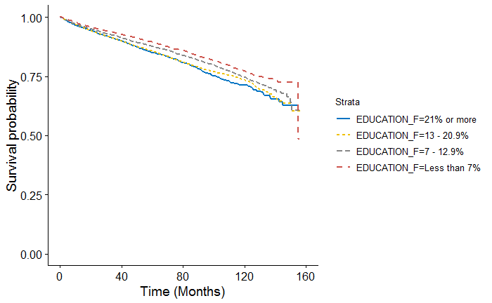

```r
uni_var(test_var = "EDUCATION_F", data_imp = data_rad)
```

### Urban/Rural

```
_________________________________________________

## U_R_F
_________________________________________________
Call: survfit(formula = Surv(DX_LASTCONTACT_DEATH_MONTHS, PUF_VITAL_STATUS ==
    0) ~ U_R_F, data = data_rad)

   1182 observations deleted due to missingness
                n events median 0.95LCL 0.95UCL
U_R_F=Metro 25042   3598     NA     155      NA
U_R_F=Urban  4222    691     NA      NA      NA
U_R_F=Rural   503     86     NA      NA      NA

Call: survfit(formula = Surv(DX_LASTCONTACT_DEATH_MONTHS, PUF_VITAL_STATUS ==
    0) ~ U_R_F, data = data_rad)

1182 observations deleted due to missingness
                U_R_F=Metro
 time n.risk n.event survival std.err lower 95% CI upper 95% CI
   12  22998     794    0.967 0.00114        0.965        0.970
   24  20438     586    0.942 0.00152        0.939        0.945
   36  17351     450    0.920 0.00181        0.916        0.923
   48  14520     416    0.896 0.00211        0.892        0.900
   60  11795     316    0.875 0.00237        0.870        0.879
  120   2106     941    0.748 0.00472        0.739        0.758

                U_R_F=Urban
 time n.risk n.event survival std.err lower 95% CI upper 95% CI
   12   3870     148    0.964 0.00290        0.958        0.970
   24   3441      98    0.939 0.00380        0.931        0.946
   36   2921      79    0.916 0.00450        0.907        0.925
   48   2424      94    0.883 0.00543        0.873        0.894
   60   1977      59    0.860 0.00609        0.848        0.872
  120    373     186    0.725 0.01135        0.703        0.747

                U_R_F=Rural
 time n.risk n.event survival std.err lower 95% CI upper 95% CI
   12    452      19    0.961 0.00879        0.944        0.978
   24    390      19    0.918 0.01271        0.894        0.944
   36    331       8    0.898 0.01434        0.870        0.927
```

[output cut: 17 more lines]

```
              coef exp(coef) se(coef)     z Pr(>|z|)
U_R_FUrban 0.12809   1.13666  0.04154 3.084  0.00204 **
U_R_FRural 0.21460   1.23937  0.10913 1.967  0.04924 *
---
Signif. codes:  0 *** 0.001 ** 0.01 * 0.05 . 0.1   1

           exp(coef) exp(-coef) lower .95 upper .95
U_R_FUrban     1.137     0.8798     1.048     1.233
U_R_FRural     1.239     0.8069     1.001     1.535

Concordance= 0.509  (se = 0.003 )
Rsquare= 0   (max possible= 0.942 )
Likelihood ratio test= 12.25  on 2 df,   p=0.002
Wald test            = 12.68  on 2 df,   p=0.002
Score (logrank) test = 12.71  on 2 df,   p=0.002
```

```
Removed 1 rows containing missing values (geom_errorbar).
```

```
## Unadjusted Kaplan Meier Overall Survival Curve for:  U_R_F
```

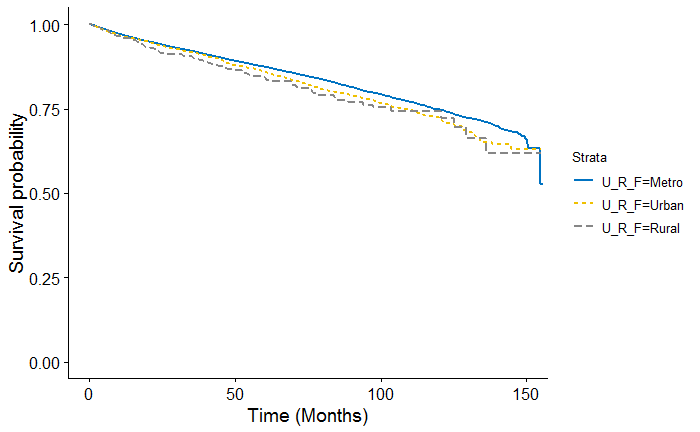

```r
uni_var(test_var = "U_R_F", data_imp = data_rad)
```

### Comorbidities

```
_________________________________________________

## CDCC_TOTAL
_________________________________________________
Call: survfit(formula = Surv(DX_LASTCONTACT_DEATH_MONTHS, PUF_VITAL_STATUS ==
    0) ~ CDCC_TOTAL, data = data_rad)

                 n events median 0.95LCL 0.95UCL
CDCC_TOTAL=0 26981   3601     NA   154.9      NA
CDCC_TOTAL=1  3054    687  140.9   133.6      NA
CDCC_TOTAL=2   653    199  112.1   107.1     128
CDCC_TOTAL=3   261     93   87.1    78.2      NA

Call: survfit(formula = Surv(DX_LASTCONTACT_DEATH_MONTHS, PUF_VITAL_STATUS ==
    0) ~ CDCC_TOTAL, data = data_rad)

                CDCC_TOTAL=0
 time n.risk n.event survival std.err lower 95% CI upper 95% CI
   12  24827     745    0.972 0.00103        0.970        0.974
   24  22157     556    0.949 0.00138        0.946        0.952
   36  18960     446    0.929 0.00165        0.925        0.932
   48  15933     425    0.906 0.00194        0.902        0.910
   60  13038     322    0.886 0.00219        0.882        0.890
  120   2425     993    0.767 0.00434        0.759        0.776

                CDCC_TOTAL=1
 time n.risk n.event survival std.err lower 95% CI upper 95% CI
   12   2751     180    0.940 0.00435        0.931        0.948
   24   2370     130    0.894 0.00571        0.883        0.905
   36   1898      75    0.862 0.00657        0.850        0.875
   48   1527      86    0.820 0.00768        0.805        0.835
   60   1186      57    0.786 0.00858        0.769        0.803
  120    162     143    0.610 0.01650        0.578        0.643

                CDCC_TOTAL=2
 time n.risk n.event survival std.err lower 95% CI upper 95% CI
   12    578      57    0.912  0.0112        0.890        0.934
   24    500      30    0.862  0.0137        0.836        0.890
   36    399      28    0.810  0.0161        0.779        0.842
   48    328      19    0.768  0.0179        0.733        0.804
```

[output cut: 26 more lines]

```
CDCC_TOTAL2 1.00414   2.72956  0.07288 13.78   <2e-16 ***
CDCC_TOTAL3 1.30280   3.67960  0.10512 12.39   <2e-16 ***
---
Signif. codes:  0 *** 0.001 ** 0.01 * 0.05 . 0.1   1

            exp(coef) exp(-coef) lower .95 upper .95
CDCC_TOTAL1     1.956     0.5112     1.803     2.123
CDCC_TOTAL2     2.730     0.3664     2.366     3.149
CDCC_TOTAL3     3.680     0.2718     2.994     4.521

Concordance= 0.557  (se = 0.003 )
Rsquare= 0.014   (max possible= 0.944 )
Likelihood ratio test= 436.9  on 3 df,   p=<2e-16
Wald test            = 531.7  on 3 df,   p=<2e-16
Score (logrank) test = 573  on 3 df,   p=<2e-16
```

```
Removed 1 rows containing missing values (geom_errorbar).
```

```
## Unadjusted Kaplan Meier Overall Survival Curve for:  CDCC_TOTAL
```

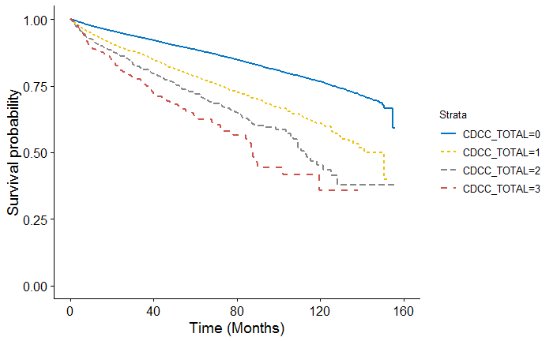

```r
uni_var(test_var = "CDCC_TOTAL", data_imp = data_rad)
```

### Year

```
_________________________________________________

## YEAR_OF_DIAGNOSIS
_________________________________________________
Call: survfit(formula = Surv(DX_LASTCONTACT_DEATH_MONTHS, PUF_VITAL_STATUS ==
    0) ~ YEAR_OF_DIAGNOSIS, data = data_rad)

                          n events median 0.95LCL 0.95UCL
YEAR_OF_DIAGNOSIS=2004 2314    558     NA   154.9      NA
YEAR_OF_DIAGNOSIS=2005 2529    620    144   143.9      NA
YEAR_OF_DIAGNOSIS=2006 2731    570     NA      NA      NA
YEAR_OF_DIAGNOSIS=2007 2733    551     NA      NA      NA
YEAR_OF_DIAGNOSIS=2008 2877    490     NA      NA      NA
YEAR_OF_DIAGNOSIS=2009 2962    465     NA      NA      NA
YEAR_OF_DIAGNOSIS=2010 3037    401     NA    83.8      NA
YEAR_OF_DIAGNOSIS=2011 2813    294     NA      NA      NA
YEAR_OF_DIAGNOSIS=2012 2917    274     NA      NA      NA
YEAR_OF_DIAGNOSIS=2013 2986    218     NA      NA      NA
YEAR_OF_DIAGNOSIS=2014 3050    139     NA      NA      NA

Call: survfit(formula = Surv(DX_LASTCONTACT_DEATH_MONTHS, PUF_VITAL_STATUS ==
    0) ~ YEAR_OF_DIAGNOSIS, data = data_rad)

                YEAR_OF_DIAGNOSIS=2004
 time n.risk n.event survival std.err lower 95% CI upper 95% CI
   12   2095      77    0.966 0.00385        0.958        0.973
   24   1972      53    0.941 0.00505        0.931        0.951
   36   1882      61    0.911 0.00613        0.899        0.923
   48   1786      64    0.880 0.00706        0.866        0.894
   60   1688      51    0.855 0.00770        0.840        0.870
  120   1056     187    0.746 0.01006        0.727        0.766

                YEAR_OF_DIAGNOSIS=2005
 time n.risk n.event survival std.err lower 95% CI upper 95% CI
   12   2339      92    0.963 0.00382        0.955        0.970
   24   2212      75    0.931 0.00513        0.921        0.941
   36   2119      55    0.908 0.00589        0.897        0.920
   48   2007      65    0.880 0.00666        0.867        0.893
   60   1906      45    0.860 0.00714        0.846        0.874
  120   1064     234    0.738 0.00965        0.720        0.757
```

[output cut: 98 more lines]

```
YEAR_OF_DIAGNOSIS2006    1.0057     0.9943    0.8924     1.134
YEAR_OF_DIAGNOSIS2007    1.0757     0.9296    0.9526     1.215
YEAR_OF_DIAGNOSIS2008    1.0009     0.9991    0.8825     1.135
YEAR_OF_DIAGNOSIS2009    1.0355     0.9657    0.9107     1.177
YEAR_OF_DIAGNOSIS2010    0.9916     1.0085    0.8671     1.134
YEAR_OF_DIAGNOSIS2011    0.9200     1.0870    0.7939     1.066
YEAR_OF_DIAGNOSIS2012    1.0016     0.9984    0.8607     1.165
YEAR_OF_DIAGNOSIS2013    0.9912     1.0088    0.8412     1.168
YEAR_OF_DIAGNOSIS2014    0.8608     1.1617    0.7092     1.045

Concordance= 0.514  (se = 0.005 )
Rsquare= 0   (max possible= 0.944 )
Likelihood ratio test= 10.44  on 10 df,   p=0.4
Wald test            = 10.29  on 10 df,   p=0.4
Score (logrank) test = 10.31  on 10 df,   p=0.4
```

```
Removed 1 rows containing missing values (geom_errorbar).
```

```
## Unadjusted Kaplan Meier Overall Survival Curve for:  YEAR_OF_DIAGNOSIS
```

```
This manual palette can handle a maximum of 10 values. You have supplied 11.Removed 915 rows containing missing values (geom_path).This manual palette can handle a maximum of 10 values. You have supplied 11.Removed 915 rows containing missing values (geom_path).
```

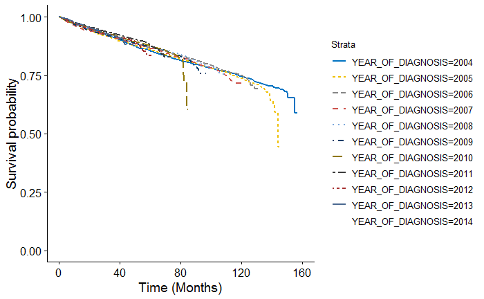

```r
uni_var(test_var = "YEAR_OF_DIAGNOSIS", data_imp = data_rad)
```

### Histology

```
_________________________________________________

## HISTOLOGY_F_LIM
_________________________________________________
Call: survfit(formula = Surv(DX_LASTCONTACT_DEATH_MONTHS, PUF_VITAL_STATUS ==
    0) ~ HISTOLOGY_F_LIM, data = data_rad)

                          n events median 0.95LCL 0.95UCL
HISTOLOGY_F_LIM=9530  14897   2689     NA     155      NA
HISTOLOGY_F_LIM=9560  11022    913     NA      NA      NA
HISTOLOGY_F_LIM=Other  5030    978     NA     150      NA

Call: survfit(formula = Surv(DX_LASTCONTACT_DEATH_MONTHS, PUF_VITAL_STATUS ==
    0) ~ HISTOLOGY_F_LIM, data = data_rad)

                HISTOLOGY_F_LIM=9530
 time n.risk n.event survival std.err lower 95% CI upper 95% CI
   12  13512     675    0.954 0.00175        0.950        0.957
   24  11977     431    0.922 0.00226        0.918        0.926
   36  10189     318    0.896 0.00263        0.891        0.901
   48   8488     301    0.867 0.00301        0.861        0.873
   60   6929     213    0.844 0.00335        0.837        0.850
  120   1231     683    0.696 0.00638        0.684        0.709

                HISTOLOGY_F_LIM=9560
 time n.risk n.event survival std.err lower 95% CI upper 95% CI
   12  10243     147    0.986 0.00113        0.984        0.988
   24   9201     127    0.973 0.00158        0.970        0.977
   36   7896     112    0.961 0.00196        0.957        0.965
   48   6680     105    0.947 0.00235        0.942        0.952
   60   5451      96    0.932 0.00276        0.927        0.938
  120   1031     282    0.846 0.00593        0.834        0.857

                HISTOLOGY_F_LIM=Other
 time n.risk n.event survival std.err lower 95% CI upper 95% CI
   12   4621     188    0.962 0.00273        0.957        0.967
   24   4029     176    0.924 0.00385        0.916        0.931
   36   3318     131    0.891 0.00465        0.882        0.900
   48   2733     136    0.852 0.00555        0.841        0.863
   60   2175      95    0.819 0.00626        0.807        0.832
```

[output cut: 14 more lines]

```
                         coef exp(coef) se(coef)       z Pr(>|z|)
HISTOLOGY_F_LIM9560  -0.83087   0.43567  0.03831 -21.689   <2e-16 ***
HISTOLOGY_F_LIMOther  0.11601   1.12301  0.03735   3.106   0.0019 **
---
Signif. codes:  0 *** 0.001 ** 0.01 * 0.05 . 0.1   1

                     exp(coef) exp(-coef) lower .95 upper .95
HISTOLOGY_F_LIM9560     0.4357     2.2953    0.4042    0.4696
HISTOLOGY_F_LIMOther    1.1230     0.8905    1.0437    1.2083

Concordance= 0.596  (se = 0.004 )
Rsquare= 0.021   (max possible= 0.944 )
Likelihood ratio test= 641.5  on 2 df,   p=<2e-16
Wald test            = 552.3  on 2 df,   p=<2e-16
Score (logrank) test = 587.5  on 2 df,   p=<2e-16
```

```
Removed 1 rows containing missing values (geom_errorbar).
```

```
## Unadjusted Kaplan Meier Overall Survival Curve for:  HISTOLOGY_F_LIM
```

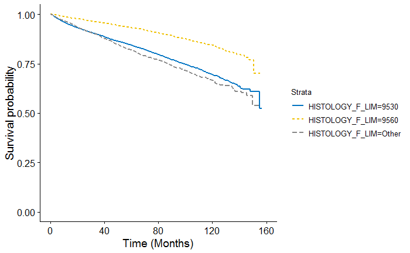

```r
uni_var(test_var = "HISTOLOGY_F_LIM", data_imp = data_rad)
```

Note: histology code 9530 represents meningioma and 9560 represents neuroma.

### Tumor Size

```
_________________________________________________

## T_SIZE
_________________________________________________
Call: survfit(formula = Surv(DX_LASTCONTACT_DEATH_MONTHS, PUF_VITAL_STATUS ==
    0) ~ T_SIZE, data = data_rad)

                            n events median 0.95LCL 0.95UCL
T_SIZE=< 1 cm            2254    187     NA      NA      NA
T_SIZE=No Tumor            10      1     NA      NA      NA
T_SIZE=Microscopic focus    5      0     NA      NA      NA
T_SIZE=1-2 cm            7937    740     NA      NA      NA
T_SIZE=2-3 cm            6299    906    155     155      NA
T_SIZE=3-4 cm            3324    659     NA      NA      NA
T_SIZE=4-5 cm            1850    392     NA      NA      NA
T_SIZE=5-6 cm            1193    234     NA     138      NA
T_SIZE=>6 cm             1640    334    150     150      NA
T_SIZE=NA_unk            6437   1127     NA      NA      NA

Call: survfit(formula = Surv(DX_LASTCONTACT_DEATH_MONTHS, PUF_VITAL_STATUS ==
    0) ~ T_SIZE, data = data_rad)

                T_SIZE=< 1 cm
 time n.risk n.event survival std.err lower 95% CI upper 95% CI
   12   2067      48    0.978 0.00315        0.972        0.984
   24   1872      28    0.964 0.00403        0.956        0.972
   36   1590      13    0.957 0.00446        0.948        0.966
   48   1321      22    0.943 0.00537        0.932        0.953
   60   1060      20    0.927 0.00632        0.915        0.939
  120    188      46    0.847 0.01389        0.820        0.875

                T_SIZE=No Tumor
 time n.risk n.event survival std.err lower 95% CI upper 95% CI
   12      9       0    1.000   0.000        1.000            1
   24      8       1    0.889   0.105        0.706            1
   36      7       0    0.889   0.105        0.706            1
   48      2       0    0.889   0.105        0.706            1
   60      1       0    0.889   0.105        0.706            1

                T_SIZE=Microscopic focus
```

[output cut: 61 more lines]

```

                T_SIZE=NA_unk
 time n.risk n.event survival std.err lower 95% CI upper 95% CI
   12   5847     224    0.964 0.00236        0.959        0.969
   24   5268     177    0.934 0.00320        0.928        0.940
   36   4645     138    0.908 0.00378        0.901        0.916
   48   4005     122    0.883 0.00432        0.874        0.891
   60   3410      97    0.860 0.00479        0.851        0.869
  120    780     328    0.726 0.00843        0.710        0.743





## Univariable Cox Proportional Hazard Model for:  T_SIZE
```

```
Loglik converged before variable  2 ; beta may be infinite.
```

```
Call:
coxph(formula = Surv(DX_LASTCONTACT_DEATH_MONTHS, PUF_VITAL_STATUS ==
    0) ~ T_SIZE, data = data_rad)

  n= 30949, number of events= 4580

                              coef  exp(coef)   se(coef)      z Pr(>|z|)
T_SIZENo Tumor           6.705e-01  1.955e+00  1.003e+00  0.669    0.504
T_SIZEMicroscopic focus -1.048e+01  2.817e-05  2.891e+02 -0.036    0.971
T_SIZE1-2 cm             9.866e-02  1.104e+00  8.185e-02  1.205    0.228
T_SIZE2-3 cm             5.714e-01  1.771e+00  8.032e-02  7.114 1.12e-12 ***
T_SIZE3-4 cm             9.357e-01  2.549e+00  8.286e-02 11.292  < 2e-16 ***
T_SIZE4-5 cm             1.045e+00  2.844e+00  8.888e-02 11.761  < 2e-16 ***
T_SIZE5-6 cm             9.766e-01  2.655e+00  9.810e-02  9.955  < 2e-16 ***
T_SIZE>6 cm              9.907e-01  2.693e+00  9.135e-02 10.846  < 2e-16 ***
T_SIZENA_unk             6.593e-01  1.933e+00  7.899e-02  8.347  < 2e-16 ***
---
Signif. codes:  0 *** 0.001 ** 0.01 * 0.05 . 0.1   1

                        exp(coef) exp(-coef)  lower .95  upper .95
T_SIZENo Tumor          1.955e+00  5.115e-01  2.740e-01  1.395e+01
T_SIZEMicroscopic focus 2.817e-05  3.549e+04 2.433e-251 3.262e+241
T_SIZE1-2 cm            1.104e+00  9.060e-01  9.401e-01  1.296e+00
T_SIZE2-3 cm            1.771e+00  5.647e-01  1.513e+00  2.073e+00
T_SIZE3-4 cm            2.549e+00  3.923e-01  2.167e+00  2.998e+00
T_SIZE4-5 cm            2.844e+00  3.516e-01  2.390e+00  3.386e+00
T_SIZE5-6 cm            2.655e+00  3.766e-01  2.191e+00  3.218e+00
T_SIZE>6 cm             2.693e+00  3.713e-01  2.252e+00  3.221e+00
T_SIZENA_unk            1.933e+00  5.172e-01  1.656e+00  2.257e+00

Concordance= 0.6  (se = 0.005 )
Rsquare= 0.017   (max possible= 0.944 )
Likelihood ratio test= 517  on 9 df,   p=<2e-16
Wald test            = 487.3  on 9 df,   p=<2e-16
Score (logrank) test = 511.4  on 9 df,   p=<2e-16
```

[output not shown]

```
## Unadjusted Kaplan Meier Overall Survival Curve for:  T_SIZE
```

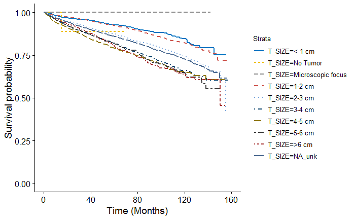

```r
uni_var(test_var = "T_SIZE", data_imp = data_rad)
```

# Multivariable Cox Proportional Hazard Ratio for subjects receiving radiation only.

```r
model_two <- coxph(Surv(DX_LASTCONTACT_DEATH_MONTHS, PUF_VITAL_STATUS == 0)
                     ~ INSURANCE_F + AGE_F + SEX_F + RACE_F + INCOME_F + U_R_F + CDCC_TOTAL +
                      FACILITY_TYPE_F + EDUCATION_F + T_SIZE + YEAR_OF_DIAGNOSIS,
                     data = data_rad)
```

```
Loglik converged before variable  28 ; beta may be infinite.
```

```r
model_two %>% summary()
```

```
Call:
coxph(formula = Surv(DX_LASTCONTACT_DEATH_MONTHS, PUF_VITAL_STATUS ==
    0) ~ INSURANCE_F + AGE_F + SEX_F + RACE_F + INCOME_F + U_R_F +
    CDCC_TOTAL + FACILITY_TYPE_F + EDUCATION_F + T_SIZE + YEAR_OF_DIAGNOSIS,
    data = data_rad)

  n= 26557, number of events= 4227
   (4392 observations deleted due to missingness)

                                                   coef  exp(coef)   se(coef)      z Pr(>|z|)
INSURANCE_FNone                               1.632e-01  1.177e+00  1.284e-01  1.271 0.203700
INSURANCE_FMedicaid                           5.961e-01  1.815e+00  8.380e-02  7.114 1.13e-12 ***
INSURANCE_FMedicare                           3.976e-01  1.488e+00  5.008e-02  7.939 2.03e-15 ***
INSURANCE_FOther Government                  -1.102e-01  8.957e-01  1.600e-01 -0.688 0.491170
INSURANCE_FUnknown                            2.051e-01  1.228e+00  1.079e-01  1.902 0.057200 .
AGE_F(54,64]                                  7.006e-01  2.015e+00  6.013e-02 11.650  < 2e-16 ***
AGE_F(64,74]                                  1.177e+00  3.243e+00  6.676e-02 17.623  < 2e-16 ***
AGE_F(74,100]                                 2.161e+00  8.679e+00  6.659e-02 32.452  < 2e-16 ***
SEX_FFemale                                  -2.720e-01  7.619e-01  3.167e-02 -8.588  < 2e-16 ***
RACE_FBlack                                   1.031e-01  1.109e+00  5.257e-02  1.961 0.049885 *
RACE_FOther/Unk                              -2.761e-01  7.587e-01  1.013e-01 -2.726 0.006414 **
RACE_FAsian                                  -2.513e-01  7.778e-01  1.023e-01 -2.457 0.014007 *
INCOME_F38k to 47k                           -1.241e-01  8.833e-01  5.147e-02 -2.411 0.015914 *
INCOME_F48k to 63k                           -2.068e-01  8.132e-01  5.490e-02 -3.766 0.000166 ***
INCOME_FOver 63k                             -1.641e-01  8.486e-01  6.258e-02 -2.623 0.008717 **
U_R_FUrban                                   -8.870e-02  9.151e-01  4.586e-02 -1.934 0.053078 .
U_R_FRural                                   -9.927e-02  9.055e-01  1.125e-01 -0.883 0.377430
CDCC_TOTAL1                                   4.087e-01  1.505e+00  4.344e-02  9.408  < 2e-16 ***
CDCC_TOTAL2                                   5.906e-01  1.805e+00  7.647e-02  7.723 1.13e-14 ***
CDCC_TOTAL3                                   1.010e+00  2.745e+00  1.094e-01  9.227  < 2e-16 ***
FACILITY_TYPE_FCommunity Cancer Program       5.582e-01  1.748e+00  8.834e-02  6.319 2.63e-10 ***
FACILITY_TYPE_FComprehensive Comm Ca Program  1.541e-01  1.167e+00  3.508e-02  4.392 1.12e-05 ***
FACILITY_TYPE_FIntegrated Network Ca Program  5.303e-02  1.054e+00  4.499e-02  1.179 0.238538
EDUCATION_F13 - 20.9%                         2.360e-02  1.024e+00  5.036e-02  0.469 0.639274
EDUCATION_F7 - 12.9%                         -3.621e-02  9.644e-01  5.451e-02 -0.664 0.506499
EDUCATION_FLess than 7%                      -1.426e-01  8.671e-01  6.434e-02 -2.217 0.026619 *
T_SIZENo Tumor                                4.010e-01  1.493e+00  1.004e+00  0.399 0.689533
T_SIZEMicroscopic focus                      -9.826e+00  5.403e-05  3.351e+02 -0.029 0.976608
T_SIZE1-2 cm                                 -4.992e-02  9.513e-01  8.391e-02 -0.595 0.551939
T_SIZE2-3 cm                                  2.244e-01  1.252e+00  8.247e-02  2.720 0.006522 **
```

[output cut: 55 more lines]

```
YEAR_OF_DIAGNOSIS2006                        1.003e+00  9.974e-01  8.842e-01  1.137e+00
YEAR_OF_DIAGNOSIS2007                        1.018e+00  9.827e-01  8.948e-01  1.157e+00
YEAR_OF_DIAGNOSIS2008                        9.982e-01  1.002e+00  8.747e-01  1.139e+00
YEAR_OF_DIAGNOSIS2009                        9.749e-01  1.026e+00  8.508e-01  1.117e+00
YEAR_OF_DIAGNOSIS2010                        9.793e-01  1.021e+00  8.506e-01  1.127e+00
YEAR_OF_DIAGNOSIS2011                        9.012e-01  1.110e+00  7.719e-01  1.052e+00
YEAR_OF_DIAGNOSIS2012                        9.617e-01  1.040e+00  8.207e-01  1.127e+00
YEAR_OF_DIAGNOSIS2013                        9.106e-01  1.098e+00  7.661e-01  1.083e+00
YEAR_OF_DIAGNOSIS2014                        8.531e-01  1.172e+00  6.983e-01  1.042e+00

Concordance= 0.775  (se = 0.005 )
Rsquare= 0.146   (max possible= 0.953 )
Likelihood ratio test= 4185  on 45 df,   p=<2e-16
Wald test            = 4019  on 45 df,   p=<2e-16
Score (logrank) test = 5226  on 45 df,   p=<2e-16
```

Summary of Model

```r
model_two %>%
        tidy(., exponentiate = TRUE) %>%
        select(term, estimate, conf.low, conf.high, p.value) %>%
        rename(Variable = term,
               Hazard_Ratio = estimate) %>%
        tbl_df %>%
        print(n = nrow(.))
```

| Variable | Hazard_Ratio | conf.low | conf.high | p.value |
| --- | --- | --- | --- | --- |
| INSURANCE_FNone | 1.177296e+00 | 9.153398e-01 | 1.514219e+00 | 2.037001e-01 |
| INSURANCE_FMedicaid | 1.815115e+00 | 1.540182e+00 | 2.139126e+00 | 1.128804e-12 |
| INSURANCE_FMedicare | 1.488257e+00 | 1.349114e+00 | 1.641750e+00 | 2.034824e-15 |
| INSURANCE_FOther Government | 8.956765e-01 | 6.545296e-01 | 1.225669e+00 | 4.911695e-01 |
| INSURANCE_FUnknown | 1.227660e+00 | 9.937442e-01 | 1.516637e+00 | 5.720020e-02 |
| AGE_F(54,64] | 2.014903e+00 | 1.790892e+00 | 2.266935e+00 | 2.281964e-31 |
| AGE_F(64,74] | 3.243201e+00 | 2.845418e+00 | 3.696594e+00 | 1.633634e-69 |
| AGE_F(74,100] | 8.679397e+00 | 7.617422e+00 | 9.889426e+00 | 5.145281e-231 |
| SEX_FFemale | 7.618589e-01 | 7.160026e-01 | 8.106522e-01 | 8.880400e-18 |
| RACE_FBlack | 1.108596e+00 | 1.000052e+00 | 1.228921e+00 | 4.988495e-02 |

[output cut: 35 more lines]

# Conclusion

The National Cancer Database includes large numbers of patients from a variety of practice settings as well as rich socioeconomic information. This database represents an excellent resource to investigate treatment patterns, survival outcomes, and how patient demographics affect treatment decisions. It also includes a wide variety of tumor types, including benign tumors of the CNS. There are currnetly no large-scale studies investigating how patient factors influence treatment decisions for these tumor types. Options for treatment include obervation, surgery, and radiation. Here, patient, tumor, and facility factors influencing the inclusion of radiation as part of initial treatment for benign tumors of the CNS are investigated along with how those factors influance overall survival. Overall, about 12% of these patients had radation as part of the their initial traetment. Young and old patients were more likely to have radiation than those in the middle ages included in the study, and the frequency of radiation decreased over time. Contrary to popular belief, sicker patients were less likely to get radiation treatment than those with lower comorbidity scores. THough not investigated here, it is possible that older patients and sicker patients had no treatment becuase it was thought their benign tumors would not have an impact on their overall lifespan as much as they would for younger and healthier patients.

The pattern of treamtment for tumor size was also interesting. The liklihood of radiation treament increased from tiny to small tumors, then decreased in medium sized tumors, then increased again with large tumors. Very small tumors likely underwent observation, or no active treatment, while slightly larger tumors are commonly irradiated as they are large enough to poentially cause symptoms but small enough that they don’t need to be removed with surgery. As tumor size increases, radiation is less effective and surgery becomes the treatment of choice. And finally, very large tumors often undergo partial surgical resection wth post-operative radtion for residual disease.

Contrary to studies looking at treatment decisions in malignant disease or other surgical fields, there were not strong socioeconomic influences on treamtent decisions. Race, income, and education did not influence treatment decisions in this population. The exception to this was insurance status, as those with private insurance were more likely to receive radiation. There were significant differences in facility type and treamtent, however. Academic and integrated cancer facilities were much more likely to utilize raditiona than community cancer centers.

There was an influence of socioeconomic factors and overall survival. Although controlling for relevant variables in the database, there are likely many unmeasured characteristics that confound this result. Better income, education, and insurance were associated with improved survival. There was also increased survival in academic and integrated cancer network faciliies as compared to community cancer programs. This is interesting as benign tumors do not cause significant morbidity or mortality. Looking at the entire population of patients with benign tumors of the CNS there was a survival advantage for those receiving radiation as well.

Overall, the above analysis represents a comprehensive analysis of patient, tumor, and facility factors that influence the decision to include radiation as part of initial treatment for benign tumors of the CNS as well as the influence these factors have on overall survival, based on data available in the NCDB. There are no similar studies of this size currently in the literature.